# R Notebook

## Tema seleccionado:

**El uso de los videojuegos durante la pandemia del covid 19 y su impacto en el rendimiento académico**

## I. Título del proyecto

**Impacto de los videojuegos en el rendimiento académico en los estudiantes de UTEC, mayo 2022**

## II. Introducción

En esta investigación se va a efectuar el análisis del crecimiento del uso de videojuegos durante la Pandemia del Covid-19 en el Perú, específicamente en los alumnos universitarios de la Universidad de Ingeniería y TecnologÍa, a su vez, el poder medir cómo estos afectan en el rendimiento académico. A lo largo de esta investigación, analizaremos como las horas de juego, sueño, estudio, el tipo de videojuego, el estilo del mismo, la sensación que genera, edad, sexo, ciclo; pueden influir positiva como negativamente en el rendimiento académico. Se buscará una relación entre estas qué pueda explicar lógicamente como estas variables, combinadas entre sí, tienen resultados diferentes.

Por lo mencionado anteriormente, el equipo se plantea el siguiente problema:

¿Cuales son los principales factores que influyen en el rendimiento académico en los estudiantes de UTEC debido al uso de los videojuegos,mayo 2022?

Por lo que se ha planteado los siguientes objetivos:

## III. Objetivos

### 3.1 Objetivo general:

Determinar el impacto que tiene el uso de los videojuegos en el rendimiento académico

### 3.2 Objetivo específicos:

1. Determinar el porcentaje de estudiantes que juegan videojuegos 2 .Porcentaje de alumnos que juegan videojuegos según Género
2. Determinar la cantidad de horas de juego por semana dependiendo del ciclo
3. Determinar la densidad de la cantidad de estudiantes por ciclo según las horas de juegos
4. Determinar la cantidad de horas de juego según el promedio ponderado
5. Determinar las horas de sueño según la cantidad de horas de juegos
6. Determina la cantidad de alumnos desaprobados según las horas de juego

## IV. Planificación

Nosotros basamos nuestra investigación en una encuesta que realizamos a los estudiantes de UTEC, ya que queríamos averiguar como influía el uso de los videojuegos en el rendimiento académico por lo cual realizamos una encuesta que contiene 23 variables, las cuales nos permitirán dale solución a nuestros objetivos ya planteados. Es por ello que esta encuesta fue realizada a los estudiantes de UTEC, la cual enviamos por correo electrónico, así como también fue difundida por cada estudiante en su respectiva carrera y en los grupos de estudio, ya que con ello no pudimos obtener la totalidad de nuestras encuestas tuvimos que ir a la universidad y pedir a las personas de manera aleatoria que por favor contestaran nuestras encuestas. De esta manera pudimos obtener los resultados de nuestra encuesta.

## v. Marco Teórico

### 5.1. Población:

La población de estudio se encuentra compuesta por los estudiantes de la Universidad de Ingeniería y Tecnología (UTEC)

### 5.3. Unidad muestral:

Estudiantes de la Universidad de Ingeniería y Tecnología(UTEC)

### 5.4 Clasificación de variables

#### a. Variables Categóricas

| Descripción | Nombre de la variable | Tipo de variable | Escala |
| --- | --- | --- | --- |
| Género de la persona encuestada | Género | Categórica | Nominal |
| Carrera de la persona encuestada | Carrera | Categórica | Nominal |
| Ciclo en la que se encuentra la persona encuestada | Ciclo | Categórica | Ordinal |
| Frecuencia con la que juega videojuegos la persona encuestada | Juegas Videojuegos | Categórica | Ordinal |
| Horas de videojuegos en la semana de exámenes por persona encuestada | Horas examen | Categórica | Ordinal |
| Plataformas que utiliza la persona encuestada para jugar videojuegos | Plataforma de juegos | Categórica | Nominal |
| Área de juego de la persona encuestada | Área de juego | Categórica | Nominal |
| Especifica si la persona encuestada juega solo (a) o con amigos (as) | Modo de jugar | Categórica | Nominal |
| Frecuencia en la que la persona encuestada juega en línea | Juego en línea | Categórica | Ordinal |
| Motivación para que la persona juegue | Razón de jugar | Categórica | Nominal |
| Importancia que le dan a los videojuegos la persona encuestada | Importancia | Categórica | Ordinal |
| Relación de los videojuegos con el rendimiento de los estudiantes | Rendimiento | Categórica | Ordinal |
| Dependencia a los videojuegos de la persona encuestada en su día a día | Dependencia | Categórica | Ordinal |
| Curso que la persona encuestada desaprobó | Curso desaprobado | Categórica | Nominal |
| Curso que la persona encuestada ha repetido | Curso repetido | Categórica | Nominal |
| Curso que la persona encuestada se desempeña mejor | Cursos mejor desempeño | Categórica | Nominal |

#### b. Variables Numérica

| Descripción | Nombre de la variable | Tipo de variable | Escala |
| --- | --- | --- | --- |
| Edad de la persona encuestada | Edad | Numérica | Discreta |
| Cantidad de cursos que está llevando la persona encuestada | Cantidad de cursos | Numérica | Continua |
| Promedio ponderado de la persona encuestada | Promedio ponderado | Numérica | Discreta |
| Horas de sueño diarias que tiene la persona encuestada | Horas de sueño (diario) | Numérica | Discreta |
| Horas de estudio diarias de la persona encuestada | Horas de estudio (diario) | Numérica | Discreta |
| Horas que juega videojuegos la persona encuestada | Horas de videojuegos (semana) | Numérica | Discreta |

Encuesta planteada: https://docs.google.com/forms/d/1_uqMnqkZhzObonlDPIAXvPtnXAx32NqireA24UL3vt0/edit

Enlace del cuestionario: https://forms.gle/rX2MyDvLPWnCjdAB7

Leer las librerias

```r
library(car)
library(readr)
library(dplyr)
```

```r
library(boxplotdbl)
library(ggplot2)
```

## VI. Limpieza de Datos

```r
DDL<- read_csv("Datos.csv")
names(DDL)
```

```
##  [1] "Marca temporal"          "Género"
##  [3] "Edad"                    "Carrera"
##  [5] "Ciclo"                   "Cantidad de curso"
##  [7] "Promedio ponderado"      "Horas de sueño"
##  [9] "Horas de estudio"        "Juegas videojuegos"
## [11] "Horas de videojuegos"    "Semana de examen"
## [13] "Plataforma"              "Area de juego"
## [15] "Modo de Jugar"           "Juego en Linea"
## [17] "Razon de Jugar"          "Importancia"
## [19] "Video Juego Rendimiento" "Dependencia"
## [21] "Curso Desaprobado"       "Curso Repetido"
## [23] "Curso Desempenado"
```

```r
summary(DDL, na.rm=TRUE)
```

```
##  Marca temporal        Género               Edad         Carrera
##  Length:258         Length:258         Min.   :15.00   Length:258
##  Class :character   Class :character   1st Qu.:19.00   Class :character
##  Mode  :character   Mode  :character   Median :20.00   Mode  :character
##                                        Mean   :20.66
##                                        3rd Qu.:22.00
##                                        Max.   :40.00
##     Ciclo           Cantidad de curso Promedio ponderado Horas de sueño
##  Length:258         Min.   :1.000     Min.   :10.56      Min.   : 3.000
##  Class :character   1st Qu.:5.000     1st Qu.:13.03      1st Qu.: 5.000
##  Mode  :character   Median :6.000     Median :14.30      Median : 6.000
##                     Mean   :5.597     Mean   :14.41      Mean   : 6.129
##                     3rd Qu.:6.000     3rd Qu.:15.65      3rd Qu.: 7.000
##                     Max.   :8.000     Max.   :20.00      Max.   :11.889
##  Horas de estudio   Juegas videojuegos Horas de videojuegos Semana de examen
##  Length:258         Length:258         Min.   : 0.000       Min.   :0.0000
##  Class :character   Class :character   1st Qu.: 2.000       1st Qu.:0.0000
##  Mode  :character   Mode  :character   Median : 3.000       Median :0.0000
##                                        Mean   : 4.953       Mean   :0.5039
##                                        3rd Qu.: 6.000       3rd Qu.:1.0000
##                                        Max.   :80.000       Max.   :8.0000
##   Plataforma        Area de juego      Modo de Jugar      Juego en Linea
##  Length:258         Length:258         Length:258         Length:258
##  Class :character   Class :character   Class :character   Class :character
##  Mode  :character   Mode  :character   Mode  :character   Mode  :character
##
##
##
##  Razon de Jugar     Importancia        Video Juego Rendimiento
##  Length:258         Length:258         Length:258
##  Class :character   Class :character   Class :character
##  Mode  :character   Mode  :character   Mode  :character
##
##
##
##  Dependencia        Curso Desaprobado  Curso Repetido     Curso Desempenado
##  Length:258         Length:258         Length:258         Length:258
##  Class :character   Class :character   Class :character   Class :character
##  Mode  :character   Mode  :character   Mode  :character   Mode  :character
##
##
##
```

### 6.1 Boxplot Varible Horas de videojuegos

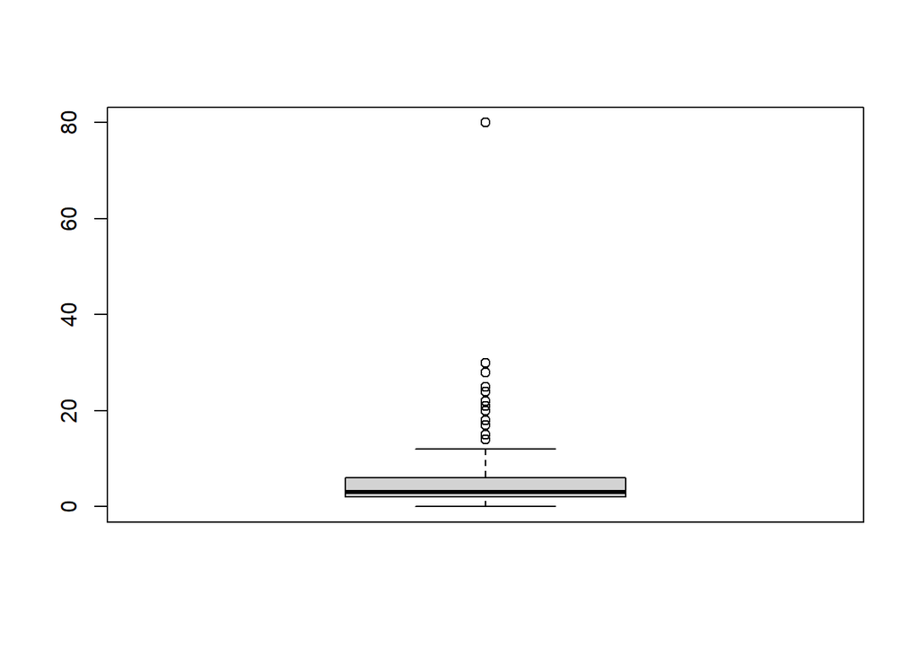

```r
boxplot(DDL$`Horas de videojuegos`) # muestra el grafico de cajas
```

```r
boxplot.stats(DDL$`Horas de videojuegos`) # imprime los valores atipicos
```

```
## $stats
## [1]  0  2  3  6 12
##
## $n
## [1] 258
##
## $conf
## [1] 2.606534 3.393466
##
## $out
##  [1] 14 25 20 21 15 80 18 17 22 14 30 14 20 14 15 20 28 24 15 15 14
```

#### a)Seleccionando solo los datos menores a mas 20 horas de juego , motivo porque los datos mayores a 20 son pocos y tienen algunos valores irregulares

```r
DDL1<-filter(DDL,`Horas de videojuegos`<20)
```

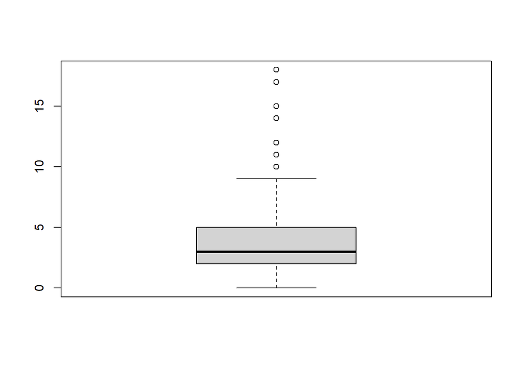

```r
boxplot(DDL1$`Horas de videojuegos`) # muestra el gráfico de cajas
```

```r
boxplot.stats(DDL1$`Horas de videojuegos`) # imprime los valores atípicos
```

```
## $stats
## [1] 0 2 3 5 9
##
## $n
## [1] 248
##
## $conf
## [1] 2.69901 3.30099
##
## $out
##  [1] 14 10 10 10 15 10 18 17 10 10 10 10 14 12 10 14 10 14 15 10 10 10 10 10 10
## [26] 15 10 15 10 11 12 14
```

### 6.2 Boxplot de la variable promedio ponderado

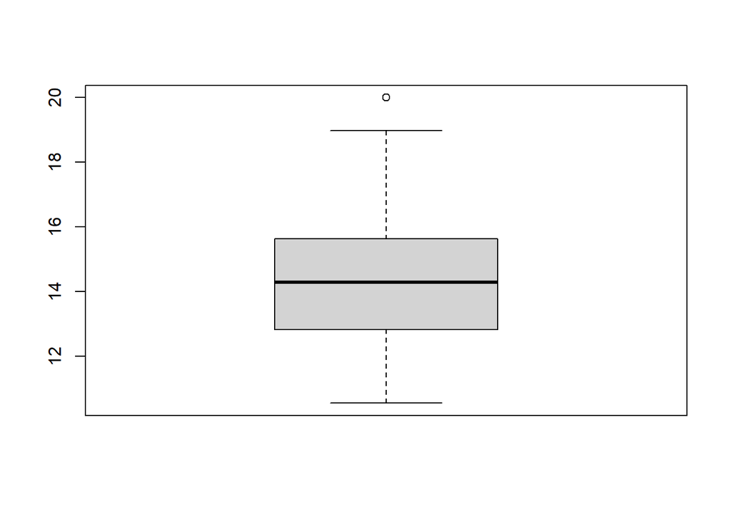

```r
boxplot(DDL1$`Promedio ponderado`) # muestra el grafico de cajas
```

```r
boxplot.stats(DDL1$`Promedio ponderado`) # imprime los valores atipicos
```

```
## $stats
## [1] 10.560 12.825 14.300 15.630 18.980
##
## $n
## [1] 248
##
## $conf
## [1] 14.01857 14.58143
##
## $out
## [1] 20
```

#### a)Seleccionando solo los datos menores a mas 20 de promedio ,motivo porque es valor irreal

```r
DDL1<-filter(DDL1,`Promedio ponderado`<20)
```

#### b)Boxplot de la variable promedio ponderado sin datos atipicos

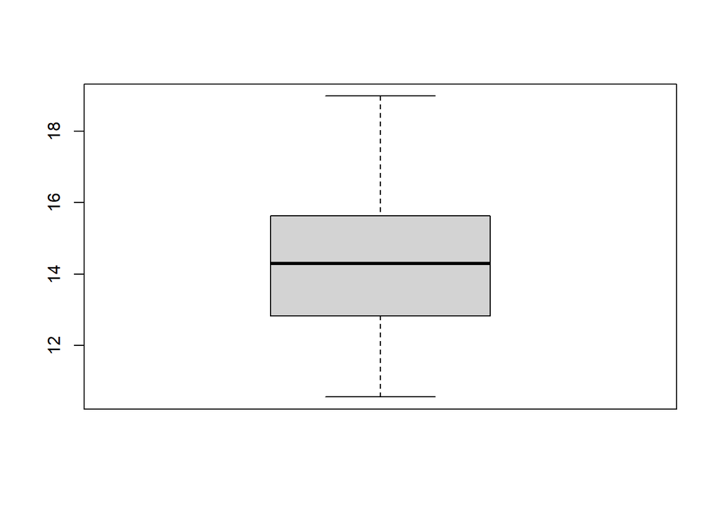

```r
boxplot(DDL1$`Promedio ponderado`) # muestra el grafico de cajas
```

```r
boxplot.stats(DDL1$`Promedio ponderado`) # imprime los valores atipicos
```

```
## $stats
## [1] 10.560 12.825 14.300 15.625 18.980
##
## $n
## [1] 247
##
## $conf
## [1] 14.01851 14.58149
##
## $out
## numeric(0)
```

### 6.3 Boxplot de la Variable Horas de Sueno

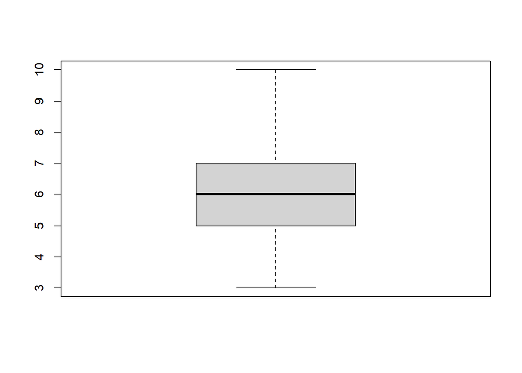

```r
boxplot(DDL1$`Horas de sueño`) # muestra el grafico de cajas
```

```r
boxplot.stats(DDL1$`Horas de sueño`) # imprime los valores atipicos
```

```
## $stats
## [1]  3  5  6  7 10
##
## $n
## [1] 247
##
## $conf
## [1] 5.798934 6.201066
##
## $out
## numeric(0)
```

Concluimos que no hay valores atipicos con la variable Horas de Sueno

### 6.4 Boxplot de la Variable Horas de estudio

```r
DDL1$`Horas de estudio`<-as.numeric(DDL1$`Horas de estudio`)
```

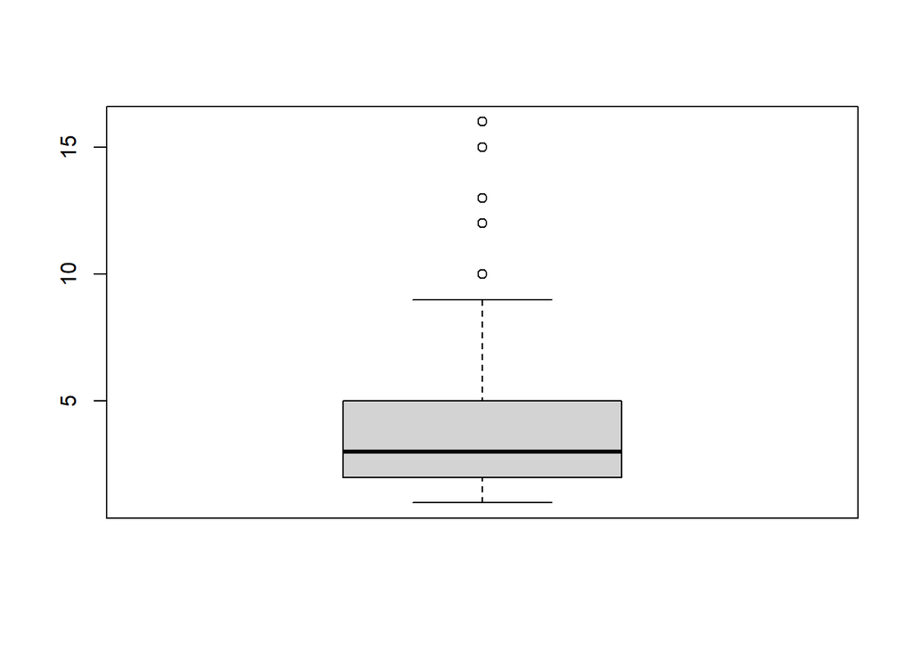

```r
boxplot(DDL1$`Horas de estudio`) # muestra el grafico de cajas
```

```r
boxplot.stats(DDL1$`Horas de estudio`) # imprime los valores atipicos
```

```
## $stats
## [1] 1 2 3 5 9
##
## $n
## [1] 247
##
## $conf
## [1] 2.698401 3.301599
##
## $out
##  [1] 12 10 10 10 15 10 16 10 13 12 15 13
```

#### a)Seleccionando solo los datos menores a mas 10 de horas de estudio ,motivo porque es valor irreal

```r
DDL1<-filter(DDL1,`Horas de estudio`<10)
```

#### b)Boxplot de la variable horas de estudio sin datos atipicos

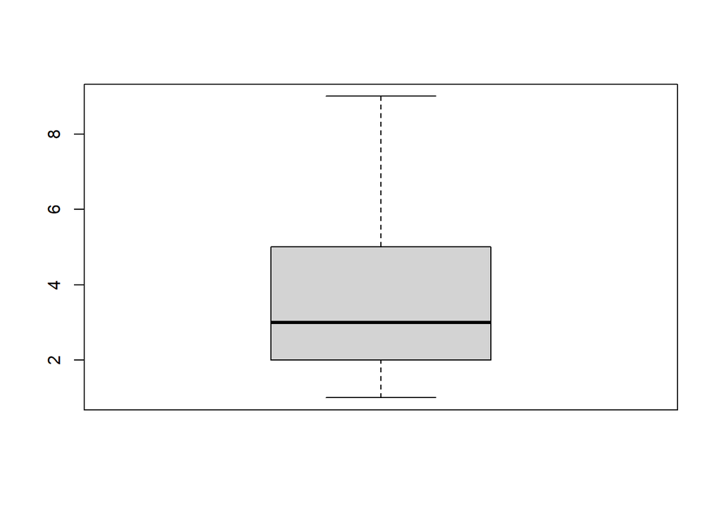

```r
boxplot(DDL1$`Horas de estudio`) # muestra el grafico de cajas
```

```r
boxplot.stats(DDL1$`Horas de estudio`) # imprime los valores sin datos atipicos
```

```
## $stats
## [1] 1 2 3 5 9
##
## $n
## [1] 235
##
## $conf
## [1] 2.690796 3.309204
##
## $out
## numeric(0)
```

### 6.5 Boxplot de la Variable Edad

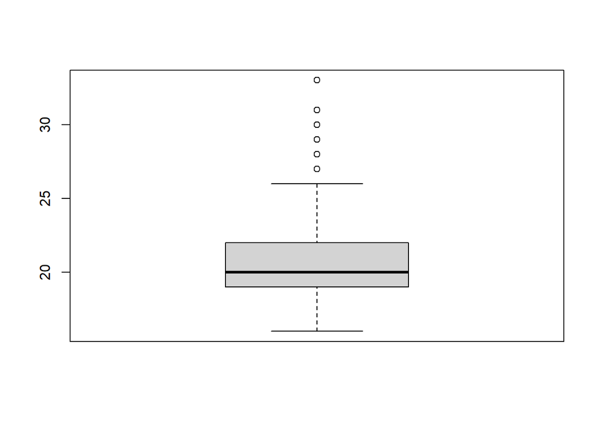

```r
boxplot(DDL1$Edad) # muestra el grafico de cajas
```

```r
boxplot.stats(DDL1$Edad) # imprime los valores atipicos
```

```
## $stats
## [1] 16 19 20 22 26
##
## $n
## [1] 235
##
## $conf
## [1] 19.6908 20.3092
##
## $out
##  [1] 29 30 29 27 33 29 28 30 31 30
```

#### a)Seleccionando solo los datos menores a 30 años de edad para nuestro estudio

```r
DDL1<-filter(DDL1,Edad<30)
```

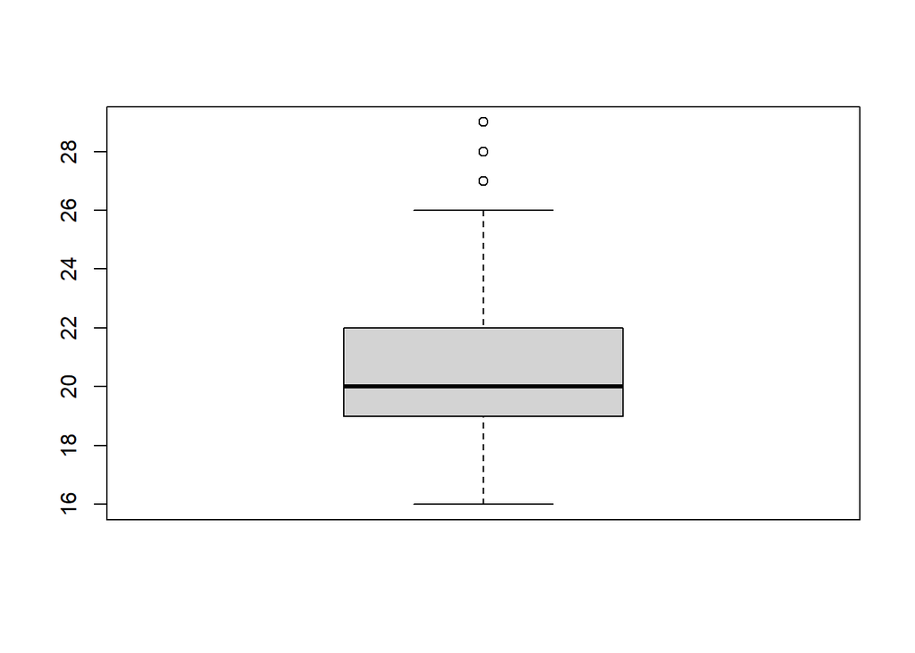

```r
boxplot(DDL1$Edad) # muestra el gráfico de cajas
```

```r
boxplot.stats(DDL1$Edad) # imprime los valores  sin datos atípicos
```

```
## $stats
## [1] 16 19 20 22 26
##
## $n
## [1] 230
##
## $conf
## [1] 19.68745 20.31255
##
## $out
## [1] 29 29 27 29 28
```

## VII. Descriptores gráficos y numéricos

### 1. Determinar el porcentaje de estudiantes que juegan videojuegos

```r
unique(DDL1$`Juegas videojuegos`)
```

```
## [1] "siempre"        "con frecuencia" "algunas veces"  "nunca"
## [5] "rara vez"
```

```r
DDL1 %>% mutate(`Juegas videojuegos`=
ifelse(`Juegas videojuegos` %in% c("siempre", "con frecuencia" , "algunas veces" ,"rara vez"), "si",
ifelse(`Juegas videojuegos`=="nunca","no",`Juegas videojuegos`
)))-> DDL1
DDL1 %>% count(`Juegas videojuegos`)
```

| Juegas videojuegos | n |
| --- | --- |
| no | 6 |
| si | 224 |

#### 1.1 Filtro de la población que solo juega video juegos

```r
DDL1_juegan<-filter(DDL1,`Juegas videojuegos`=="si" & `Horas de videojuegos`>0)
```

#### 1.2 Porcentaje de quienes juegan videojuegos

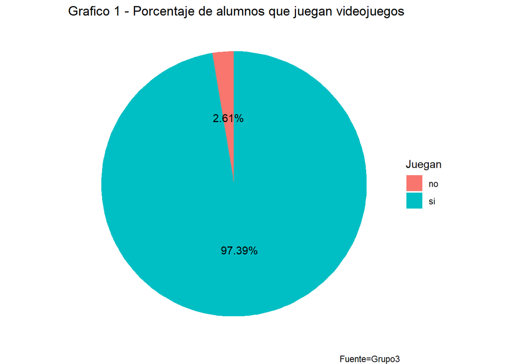

```r
# Crea Data
gente_juega <- data.frame(
Juegan=c("si","no"),
porcentaje=c(round(nrow(DDL1[DDL1$`Juegas videojuegos`=="si",])/nrow(DDL1)*100,2),
round(nrow(DDL1[DDL1$`Juegas videojuegos`=="no",])/nrow(DDL1)*100,2))
)
ggplot(gente_juega, aes(x="", y=porcentaje, fill=Juegan)) +
geom_bar(stat="identity") +
geom_text(aes(label=paste0(porcentaje,"%")),position=position_stack(vjust = .5))+
coord_polar(theta="y") +
  labs(title = "Grafico 1 - Porcentaje de alumnos que juegan videojuegos",
       caption = 'Fuente=Grupo3')+

theme_void()
```

Nuestra variable juegas videojuegos fue de tipo categórica ordinal por lo que lo hicimos en una escala( nunca,rara vez,algunas veces, con frecuencia, siempre) . Es por ello que para hallar el porcentaje de los estudiantes que juegan videojuegos y los que no juegan, tuvimos que igualar “nunca” con “No”, mientras que “rara vez”,“algunas veces”, “con frecuencia”, “siempre” igualamos con “Si”, para de esta manera poder obtener el numero de personas que si juegan videojuegos y el numero de personas que no juegan, y con este numero poder obtener el porcentaje de estudiantes que juegan videojuegos y los que no juegan.

Resultados obtenidos:

- El porcentaje de estudiantes que si juegan videojuegos es un 97.39%, entre mujeres y varones.
- El porcentaje de estudiantes que no juegan videojuegos es un 2.61%, entre mujeres y varones.

### 2 .Porcentaje de alumnos que juegan videojuegos según Genero

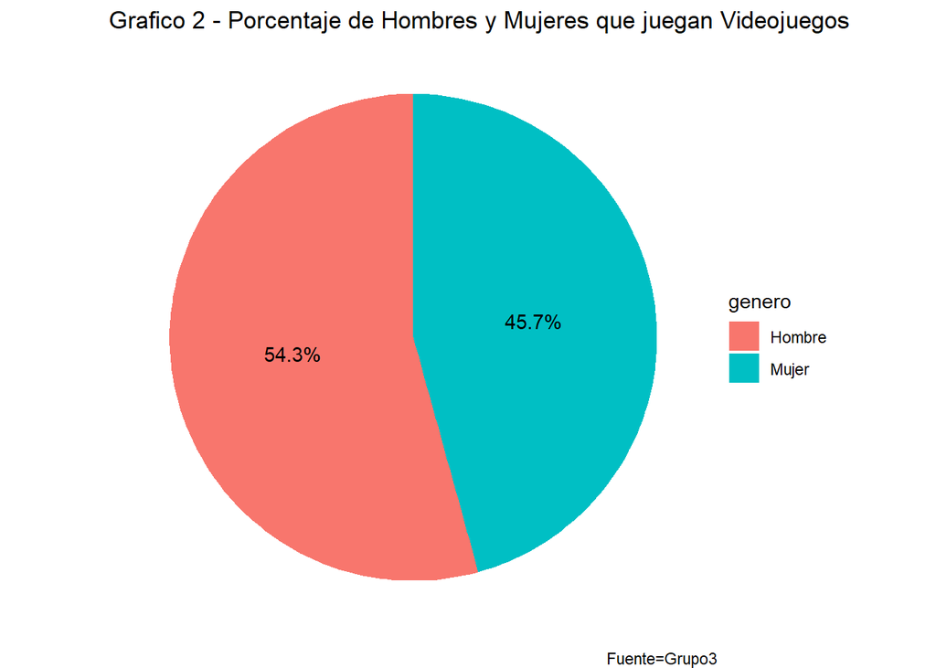

```r
# Crea Data
Datass <- data.frame(
genero=c("Hombre","Mujer"),
porcentaje=c(round(nrow(DDL1_juegan[DDL1_juegan$Género=="Hombre",])/nrow(DDL1_juegan)*100,2),
round(nrow(DDL1_juegan[DDL1_juegan$Género=="Mujer",])/nrow(DDL1_juegan)*100,2))
)
ggplot(Datass, aes(x="", y=porcentaje, fill=genero)) +
geom_bar(stat="identity") +
geom_text(aes(label=paste0(porcentaje,"%")),position=position_stack(vjust = .5))+
coord_polar(theta="y") +
    labs(title = "Grafico 2 - Porcentaje de Hombres y Mujeres que juegan Videojuegos",
       caption = 'Fuente=Grupo3')+

theme_void()
```

A partir de la data generada en el gráfico 1, se toman a los estudiantes que si juegan para poder clasificaros según el genero ya que es un variable categórica nominal, es por ello que contamos cuantos estudiantes hombres juegan y cuantas estudiantes mujeres juegan, para después sacar el porcentaje de cada uno. El gráfico nos da a entender que la mayoría de nuestros encuestados que si juegan videojuegos, tiene un diferencia mínima relativa.

### 3. Determinar la cantidad de horas de juego por semana dependiendo del ciclo

#### 3.1CREANDO DATA

```r
ciclo_h_juegos<-data.frame(
  ciclo=c("a) I","b) II","c) III","d) IV","e) V","f) VI","g) VII","h) VIII","i) IX","j) X"),
  Horas_de_juego=c(
    round(mean((filter(DDL1_juegan,`Ciclo`=="I"))$`Horas de videojuegos`),2),
    round(mean((filter(DDL1_juegan,`Ciclo`=="II"))$`Horas de videojuegos`),2),
    round(mean((filter(DDL1_juegan,`Ciclo`=="III"))$`Horas de videojuegos`),2),
    round(mean((filter(DDL1_juegan,`Ciclo`=="IV"))$`Horas de videojuegos`),2),
    round(mean((filter(DDL1_juegan,`Ciclo`=="V"))$`Horas de videojuegos`),2),
    round(mean((filter(DDL1_juegan,`Ciclo`=="VI"))$`Horas de videojuegos`),2),
    round(mean((filter(DDL1_juegan,`Ciclo`=="VII"))$`Horas de videojuegos`),2),
    round(mean((filter(DDL1_juegan,`Ciclo`=="VIII"))$`Horas de videojuegos`),2),
    round(mean((filter(DDL1_juegan,`Ciclo`=="IX"))$`Horas de videojuegos`),2),
    round(mean((filter(DDL1_juegan,`Ciclo`=="X"))$`Horas de videojuegos`),2)
  )

)
```

#### 3.2 GRAFICO DE CICLO VS HORAS DE JUEGO POR SEMANA

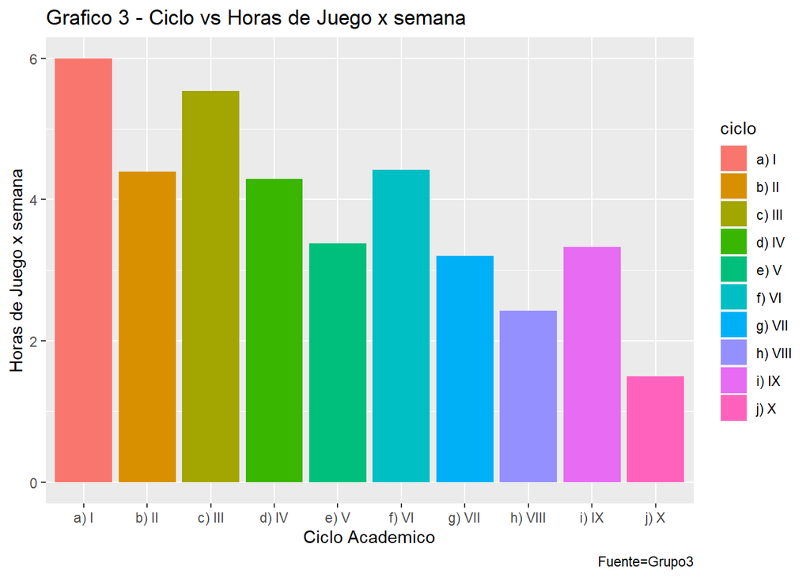

```r
ggplot(ciclo_h_juegos,aes(x=ciclo, y=Horas_de_juego, fill=ciclo))+ geom_bar(position = "dodge", stat = "identity")+
      labs(title = "Grafico 3 - Ciclo vs Horas de Juego x semana",
       x="Ciclo Academico",
       y="Horas de Juego x semana",
       caption = 'Fuente=Grupo3')
```

#### 3.3 Descriptores de la variable de Horas de juego

```r
cat('Media:',round(mean(DDL1$`Horas de videojuegos`, na.rm=TRUE),2),'\n')
```

```
## Media: 4.09
```

```r
cat('Mediana:',round(median(DDL1$`Horas de videojuegos`, na.rm=TRUE),2),'\n')
```

```
## Mediana: 3
```

```r
cat('Desviación Estándar:',round(sd(DDL1$`Horas de videojuegos`, na.rm=TRUE),2),'\n')
```

```
## Desviación Estándar: 3.7
```

```r
cat('Rango:',round(range(DDL1$`Horas de videojuegos`, na.rm=TRUE),2),'\n')
```

```
## Rango: 0 18
```

```r
cat('Rango Intercuartílico:',round(IQR(DDL1$`Horas de videojuegos`, na.rm=TRUE),2),'\n')
```

```
## Rango Intercuartílico: 3
```

```r
cat('Coeficiente de Variación:', round((sd(DDL1$`Horas de videojuegos`, na.rm=TRUE)/mean(DDL1$`Promedio ponderado`, na.rm=TRUE))*100,2),'\n')
```

```
## Coeficiente de Variación: 25.72
```

#### Interpretación de la grafica

El gráfico nos muestra que , cuan mayor se el ciclo académico de los estudiantes, menor sera la cantidad de horas que le dedican a los videojuegos, esto puede ser debido a el incremento de cursos o complejidad de los cursos en ciclos académicos que hace que los estudiantes le dediquen menos horas a los videojuegos.

### 4. Determinar la densidad de la cantidad de estudiantes por ciclo según las horas de juegos

####4.1 GRAFICO DE DENSIDAD DE HORAS DE JUEGO POR SEMANA

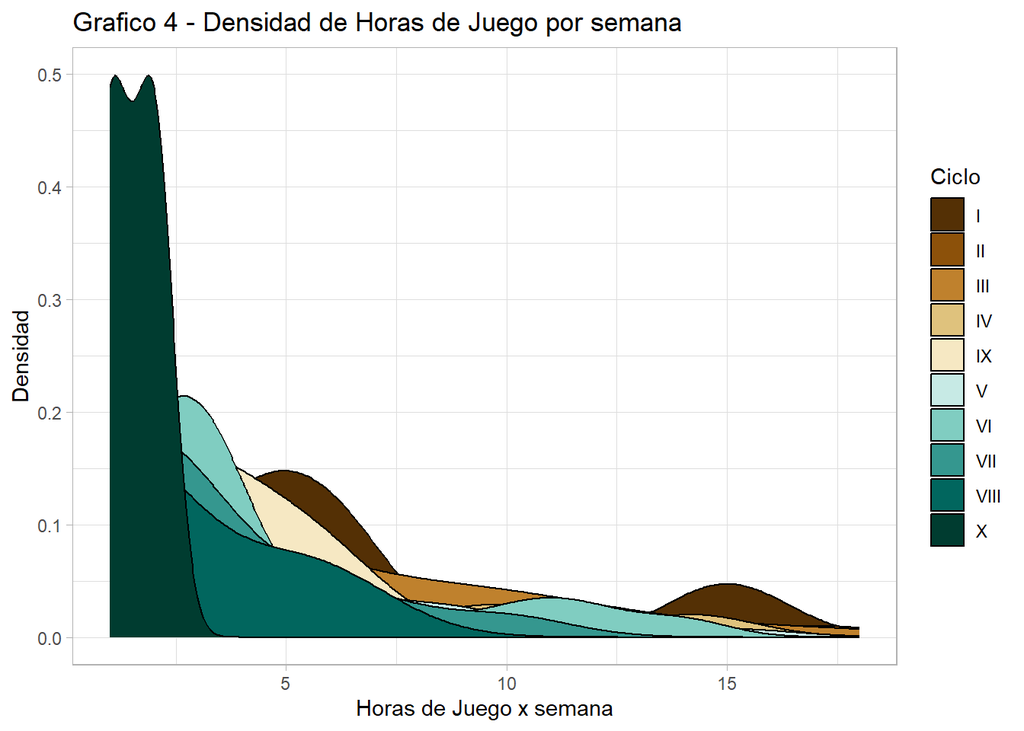

```r
ggplot(DDL1_juegan) +
  aes(x = `Horas de videojuegos`, fill = Ciclo) +
  geom_density(adjust = 1.5) +
  scale_fill_brewer(palette = "BrBG", direction =1) +
labs(x = "Horas de Juego x semana", y = "Densidad", title = "Grafico 4 - Densidad de Horas de Juego por semana")+
  theme_light()
```

#### 4.2 Descriptores de la variable de Horas de juego

```r
cat('Media:',round(mean(DDL1$`Horas de videojuegos`, na.rm=TRUE),2),'\n')
```

```
## Media: 4.09
```

```r
cat('Mediana:',round(median(DDL1$`Horas de videojuegos`, na.rm=TRUE),2),'\n')
```

```
## Mediana: 3
```

```r
cat('Desviación Estándar:',round(sd(DDL1$`Horas de videojuegos`, na.rm=TRUE),2),'\n')
```

```
## Desviación Estándar: 3.7
```

```r
cat('Rango:',round(range(DDL1$`Horas de videojuegos`, na.rm=TRUE),2),'\n')
```

```
## Rango: 0 18
```

```r
cat('Rango Intercuartílico:',round(IQR(DDL1$`Horas de videojuegos`, na.rm=TRUE),2),'\n')
```

```
## Rango Intercuartílico: 3
```

```r
cat('Coeficiente de Variación:', round((sd(DDL1$`Horas de videojuegos`, na.rm=TRUE)/mean(DDL1$`Promedio ponderado`, na.rm=TRUE))*100,2),'\n')
```

```
## Coeficiente de Variación: 25.72
```

#### 4.3 Interpretación de la grafica

Este gráfico de densidad nos es muy útil, ver la distribución de los estudiantes por ciclo con relación a las horas que le dedican a los juegos. La gráfica nos muestra que mientras sea mayor sean los ciclos académicos,los estudiantes comienzan a disminuir las horas que le dedican a los juegos ; como podemos observar compraron la gráfica de densidad respectiva para Primer Ciclo I y los de Décimo Ciclo X ,la gráfica se va contrayendo a la izquierda disminuyendo las horas de juego conforme van avanzando en sus carreras (Tendencia a disminuir según se avanza el ciclo).

#5. Determinar la cantidad de horas de juego según el promedio ponderado

#### 5.1 CREANDO DATA

```r
h_juego_promdeio<-data.frame(
  Horas=c("a) 0:3","b) 3:6","c) 6:9","d) 9:12","e) 12:15","f) 15:18"),
  Promedio=c(
    round(mean((filter(DDL1_juegan,`Horas de videojuegos`>0 &`Horas de videojuegos`<3))$`Promedio ponderado`),2),
    round(mean((filter(DDL1_juegan,`Horas de videojuegos`>3 &`Horas de videojuegos`<6))$`Promedio ponderado`),2),
    round(mean((filter(DDL1_juegan,`Horas de videojuegos`>6 &`Horas de videojuegos`<9))$`Promedio ponderado`),2),
    round(mean((filter(DDL1_juegan,`Horas de videojuegos`>9 &`Horas de videojuegos`<12))$`Promedio ponderado`),2),
    round(mean((filter(DDL1_juegan,`Horas de videojuegos`>12 &`Horas de videojuegos`<15))$`Promedio ponderado`),2),
    round(mean((filter(DDL1_juegan,`Horas de videojuegos`>15 &`Horas de videojuegos`<18))$`Promedio ponderado`),2)
  )

)
```

#### 5.2 GRAFICO DE HORAS DE JUEGO VS PROMEDIO

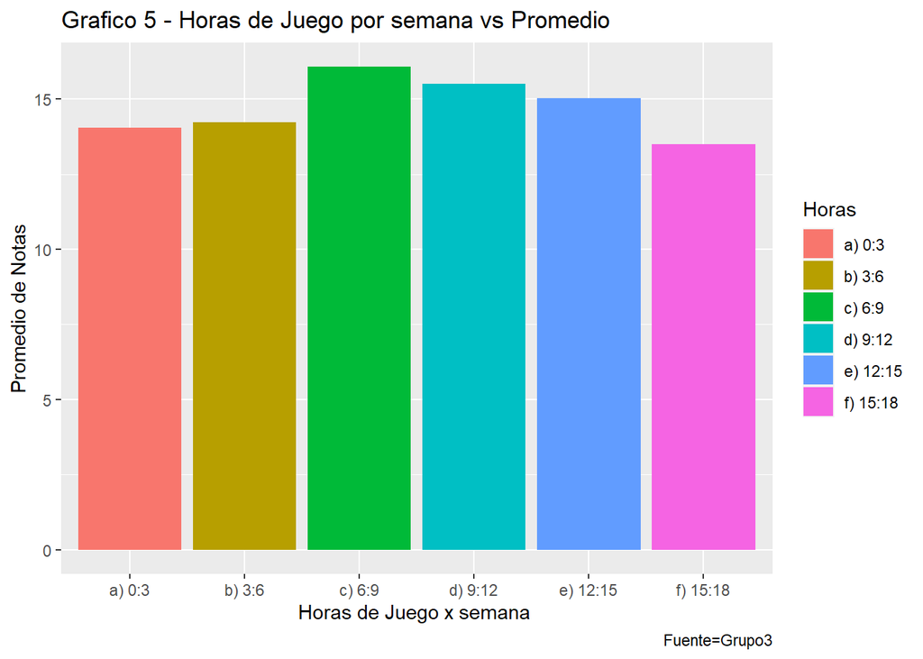

```r
ggplot(h_juego_promdeio
       ,aes(x=Horas, y=Promedio, fill=Horas))+ geom_bar(position = "dodge", stat = "identity")+
      labs(title = "Grafico 5 - Horas de Juego por semana vs Promedio",
       x="Horas de Juego x semana ",
       y="Promedio de Notas",
       caption = 'Fuente=Grupo3')
```

#### 5.3 Descriptores de la variable Promedio Ponderado

```r
cat('Media:',round(mean(DDL1$`Promedio ponderado`, na.rm=TRUE),2),'\n')
```

```
## Media: 14.4
```

```r
cat('Mediana:',round(median(DDL1$`Promedio ponderado`, na.rm=TRUE),2),'\n')
```

```
## Mediana: 14.32
```

```r
cat('Desviación Estándar:',round(sd(DDL1$`Promedio ponderado`, na.rm=TRUE),2),'\n')
```

```
## Desviación Estándar: 1.94
```

```r
cat('Rango:',round(range(DDL1$`Promedio ponderado`, na.rm=TRUE),2),'\n')
```

```
## Rango: 10.56 18.98
```

```r
cat('Rango Intercuartílico:',round(IQR(DDL1$`Promedio ponderado`, na.rm=TRUE),2),'\n')
```

```
## Rango Intercuartílico: 2.64
```

```r
cat('Coeficiente de Variación:', round((sd(DDL1$`Promedio ponderado`, na.rm=TRUE)/mean(DDL1$`Promedio ponderado`, na.rm=TRUE))*100,2),'\n')
```

```
## Coeficiente de Variación: 13.49
```

La nota promedio de los estudiantes de UTEC es de 14.4. La mediana del promedio ponderado de los estudiantes de UTEC es 14.32 El rango de notas esta entre 10.56 - 18.98. La desviación estándar del promedio ponderado es 1.94 El rango intercuartílico del promedio ponderado es de 2.64 El coeficiente de variación del promedio ponderado es de 13.49

#### 5.4 Descriptores de la variable de Horas de juego

```r
cat('Media:',round(mean(DDL1$`Horas de videojuegos`, na.rm=TRUE),2),'\n')
```

```
## Media: 4.09
```

```r
cat('Mediana:',round(median(DDL1$`Horas de videojuegos`, na.rm=TRUE),2),'\n')
```

```
## Mediana: 3
```

```r
cat('Desviación Estándar:',round(sd(DDL1$`Horas de videojuegos`, na.rm=TRUE),2),'\n')
```

```
## Desviación Estándar: 3.7
```

```r
cat('Rango:',round(range(DDL1$`Horas de videojuegos`, na.rm=TRUE),2),'\n')
```

```
## Rango: 0 18
```

```r
cat('Rango Intercuartílico:',round(IQR(DDL1$`Horas de videojuegos`, na.rm=TRUE),2),'\n')
```

```
## Rango Intercuartílico: 3
```

```r
cat('Coeficiente de Variación:', round((sd(DDL1$`Horas de videojuegos`, na.rm=TRUE)/mean(DDL1$`Promedio ponderado`, na.rm=TRUE))*100,2),'\n')
```

```
## Coeficiente de Variación: 25.72
```

#### 5.5 Interpretación de la grafica:

Concluimos que los estudiantes que juegan entre 6 - 9 horas por semana tiene un promedio mayor a 15, cuando los estudiantes juegan más de 9 horas por semana, su promedio va disminuyendo. ### 6. Determinar las horas de sueño según la cantidad de horas de juegos

#### 6.1 CREANDO DATA

```r
h_juego_sueno<-data.frame(
  Horas=c("a) 0:3","b) 3:6","c) 6:9","d) 9:12","e) 12:15","f) 15:18"),
  Promedio=c(
    round(mean((filter(DDL1_juegan,`Horas de videojuegos`>0 &`Horas de videojuegos`<3))$`Horas de sueño`),2),
    round(mean((filter(DDL1_juegan,`Horas de videojuegos`>3 &`Horas de videojuegos`<6))$`Horas de sueño`),2),
    round(mean((filter(DDL1_juegan,`Horas de videojuegos`>6 &`Horas de videojuegos`<9))$`Horas de sueño`),2),
    round(mean((filter(DDL1_juegan,`Horas de videojuegos`>9 &`Horas de videojuegos`<12))$`Horas de sueño`),2),
    round(mean((filter(DDL1_juegan,`Horas de videojuegos`>12 &`Horas de videojuegos`<15))$`Horas de sueño`),2),
    round(mean((filter(DDL1_juegan,`Horas de videojuegos`>15 &`Horas de videojuegos`<18))$`Horas de sueño`),2)
  )

)
```

#### 6.2 GRAFICO HORAS DE JUEGO VS HORAS DE SUEÑO

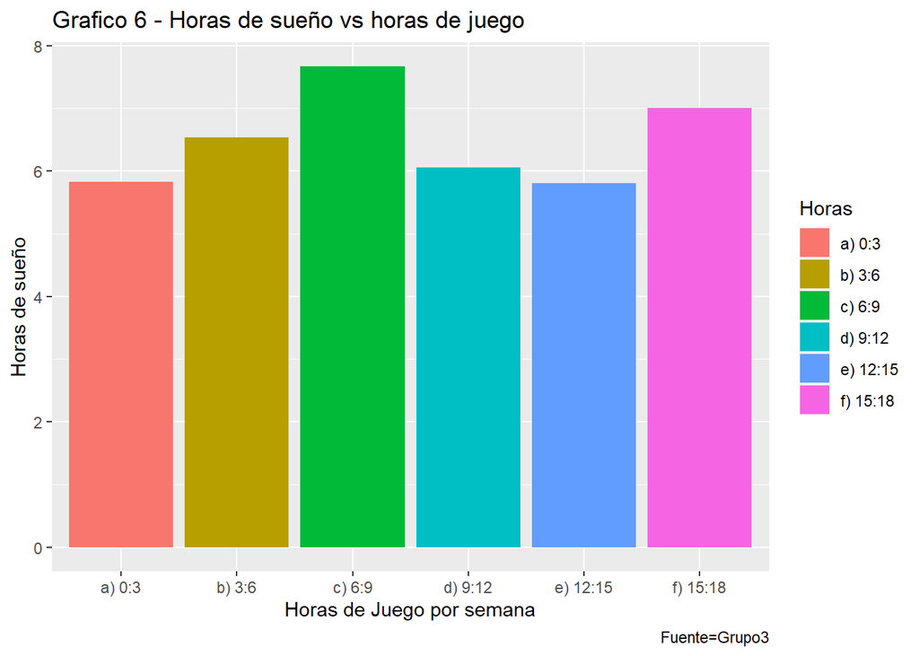

```r
ggplot(h_juego_sueno
       ,aes(x=Horas, y=Promedio, fill=Horas))+ geom_bar(position = "dodge", stat = "identity")+
      labs(title = "Grafico 6 - Horas de sueño vs horas de juego",
       x="Horas de Juego por semana",
       y="Horas de sueño",
       caption = 'Fuente=Grupo3')
```

#### 6.3 Descriptores de la variable de Horas de juego

```r
cat('Media:',round(mean(DDL1$`Horas de videojuegos`, na.rm=TRUE),2),'\n')
```

```
## Media: 4.09
```

```r
cat('Mediana:',round(median(DDL1$`Horas de videojuegos`, na.rm=TRUE),2),'\n')
```

```
## Mediana: 3
```

```r
cat('Desviación Estándar:',round(sd(DDL1$`Horas de videojuegos`, na.rm=TRUE),2),'\n')
```

```
## Desviación Estándar: 3.7
```

```r
cat('Rango:',round(range(DDL1$`Horas de videojuegos`, na.rm=TRUE),2),'\n')
```

```
## Rango: 0 18
```

```r
cat('Rango Intercuartílico:',round(IQR(DDL1$`Horas de videojuegos`, na.rm=TRUE),2),'\n')
```

```
## Rango Intercuartílico: 3
```

```r
cat('Coeficiente de Variación:', round((sd(DDL1$`Horas de videojuegos`, na.rm=TRUE)/mean(DDL1$`Promedio ponderado`, na.rm=TRUE))*100,2),'\n')
```

```
## Coeficiente de Variación: 25.72
```

#### 6.4 Descriptores de la variable de Horas de sueño

```r
cat('Media:',round(mean(DDL1$`Horas de sueño`, na.rm=TRUE),2),'\n')
```

```
## Media: 6.15
```

```r
cat('Mediana:',round(median(DDL1$`Horas de sueño`, na.rm=TRUE),2),'\n')
```

```
## Mediana: 6
```

```r
cat('Desviación Estándar:',round(sd(DDL1$`Horas de sueño`, na.rm=TRUE),2),'\n')
```

```
## Desviación Estándar: 1.32
```

```r
cat('Rango:',round(range(DDL1$`Horas de sueño`, na.rm=TRUE),2),'\n')
```

```
## Rango: 3 10
```

```r
cat('Rango Intercuartílico:',round(IQR(DDL1$`Horas de sueño`, na.rm=TRUE),2),'\n')
```

```
## Rango Intercuartílico: 2
```

```r
cat('Coeficiente de Variación:', round((sd(DDL1$`Horas de sueño`, na.rm=TRUE)/mean(DDL1$`Promedio ponderado`, na.rm=TRUE))*100,2),'\n')
```

```
## Coeficiente de Variación: 9.2
```

### 7. Determina la cantidad de alumnos desaprobados según las horas de juego

#### 7.1 GRAFICO DE HORAS DE JUEGO POR SEMANA CON CANTIDAD DE ALUMNOS DESAPROBADOS

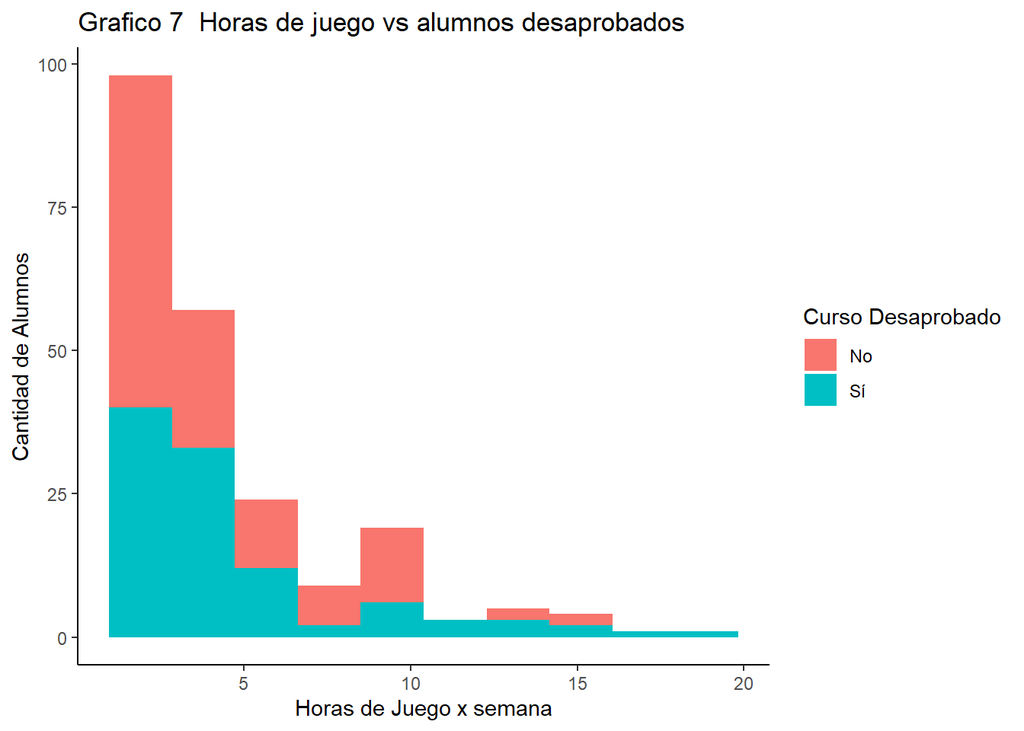

```r
DDL1_juegan %>%
 ggplot() +
  aes(x = `Horas de videojuegos`, fill = `Curso Desaprobado`) +
  geom_histogram(bins = 10L) +
  scale_fill_hue(direction = 1) +
  labs(x = "Horas de Juego x semana", y = "Cantidad de Alumnos", title = "Grafico 7  Horas de juego vs alumnos desaprobados")+
  theme_classic()
```

## VIII. REGRESION LINEAL

#### 8.1 Regresion lineal de Horas de Juego x semana vs Horas de Sueño

```r
cor(DDL1_juegan$`Horas de videojuegos`,DDL1_juegan$`Horas de sueño`)#Correlación
```

```
## [1] 0.1634066
```

#### a) Grafico 8 - Regresión lineal de Horas de Juego x semana vs Horas de Sueño

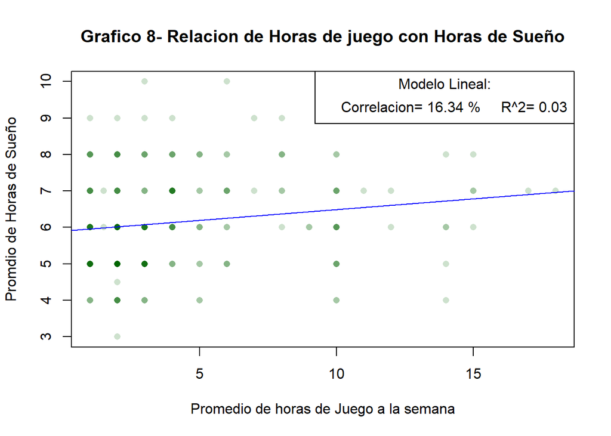

```r
plot(DDL1_juegan$`Horas de videojuegos`,DDL1_juegan$`Horas de sueño`,col=rgb(0,100,0,50,maxColorValue=255), pch=16, ylab = "Promdio de Horas de Sueño", xlab = "Promedio de horas de Juego a la semana",main="Grafico 8- Relacion de Horas de juego con Horas de Sueño")
regresion1 <- lm(DDL1_juegan$`Horas de sueño` ~ DDL1_juegan$`Horas de videojuegos`)
legend("topright",
       legend = c(paste("Correlacion=",round(cor(DDL1_juegan$`Horas de videojuegos`,DDL1_juegan$`Horas de sueño`)*100,2),"%    ","R^2=",round(cor(DDL1_juegan$`Horas de videojuegos`,DDL1_juegan$`Horas de sueño`)^2,2))),
       title = "Modelo Lineal:")
abline(regresion1, col='blue')
```

```r
summary(regresion1)
```

```
##
## Call:
## lm(formula = DDL1_juegan$`Horas de sueño` ~ DDL1_juegan$`Horas de videojuegos`)
##
## Residuals:
##     Min      1Q  Median      3Q     Max
## -3.0185 -1.0185 -0.0774  0.8636  3.9226
##
## Coefficients:
##                                    Estimate Std. Error t value Pr(>|t|)
## (Intercept)                         5.90063    0.13523  43.633   <2e-16 ***
## DDL1_juegan$`Horas de videojuegos`  0.05894    0.02405   2.451    0.015 *
## ---
## Signif. codes:  0 '***' 0.001 '**' 0.01 '*' 0.05 '.' 0.1 ' ' 1
##
## Residual standard error: 1.313 on 219 degrees of freedom
## Multiple R-squared:  0.0267, Adjusted R-squared:  0.02226
## F-statistic: 6.008 on 1 and 219 DF,  p-value: 0.01502
```

#### b) Interpretación de la grafica

En esta gráfica buscábamos la relación del promedio de horas de juego a la semana con el promedio de horas de sueño de un estudiante , nuestra intuición nos dice que entre más horas le dedique el estudiante a los videojuegos este tendría que tener un menor tiempo de horas para dormir ,por lo que la relación entre estas dos variables sea inversa , pero al hacer la regresión lineal , nos dice que existe una relación directa muy débil por el coeficiente de determinación (R^2). Esto lo podríamos interpretar de modo que la variable promedio horas de juego sea un indicador que nos indique el tiempo libre del estudiante y que entre más tiempo libre tenga ,según la intuición , este tendría a dormir mas , un caso contrario ocurría si tiene menos horas de juego (menos tiempo libre) ,puede ser por trabajos o exámenes) ,nuestra intuición nos dice que si que el estudiante tendría menos tiempo para dormir ,que es algo que generalmente ocurre el los alumnos que llevan muchos cursos o tiene mucho proyectos que entregar que se quedan sin tiempo libre para ellos; por lo cual si tendría sentido la relación directa que nos muestra la regresión lineal. Si bien podría existe otro mejor tipo de regresión que tenga una mejor aproximación, que nos de con mayor claridad esta relación.

### 8.2 Regresion lineal de Edad vs Horas de Juego

```r
cor(DDL1_juegan$Edad,DDL1_juegan$`Horas de videojuegos`)#Correlacion
```

```
## [1] -0.2571182
```

#### a) Grafico 9 - Regresion lineal de Edad vs Horas de Juego

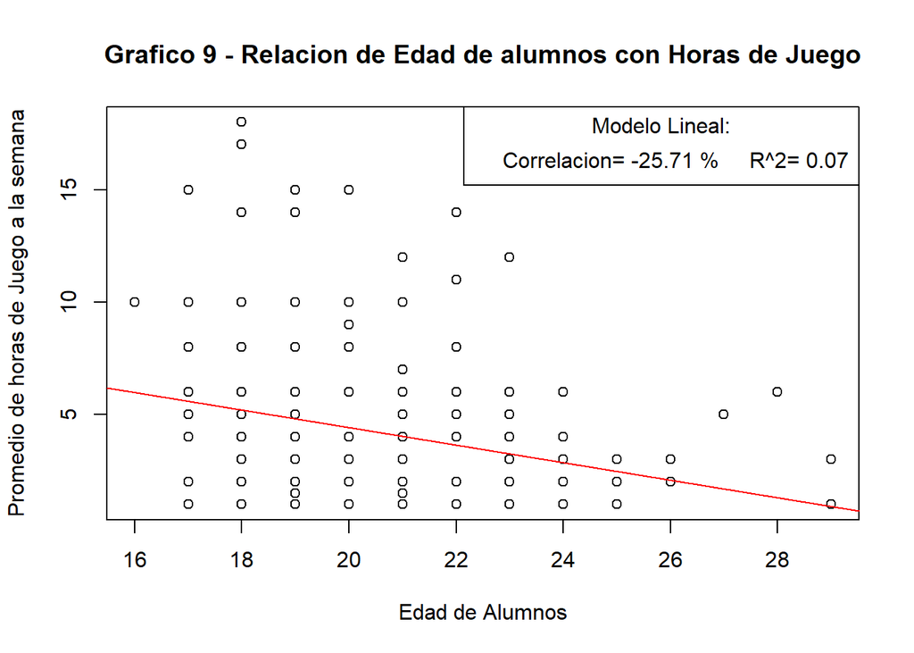

```r
regresion2 <- lm( DDL1_juegan$`Horas de videojuegos` ~ DDL1_juegan$Edad)

plot(DDL1_juegan$Edad,DDL1_juegan$`Horas de videojuegos`, ylab = "Promedio de horas de Juego a la semana", xlab = "Edad de Alumnos",main="Grafico 9 - Relacion de Edad de alumnos con Horas de Juego")
legend("topright",
       legend = c(paste("Correlacion=",round(cor(DDL1_juegan$Edad,DDL1_juegan$`Horas de videojuegos`)*100,2),"%    ","R^2=",round(cor(DDL1_juegan$Edad,DDL1_juegan$`Horas de videojuegos`)^2,2))),
       title = "Modelo Lineal:")
abline(regresion2,col='red')
```

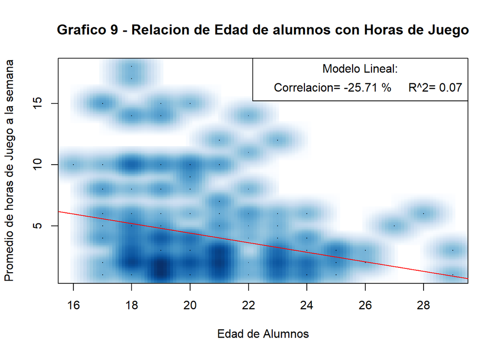

```r
smoothScatter(DDL1_juegan$Edad,DDL1_juegan$`Horas de videojuegos`, ylab = "Promedio de horas de Juego a la semana", xlab = "Edad de Alumnos",main="Grafico 9 - Relacion de Edad de alumnos con Horas de Juego")

legend("topright",
       legend = c(paste("Correlacion=",round(cor(DDL1_juegan$Edad,DDL1_juegan$`Horas de videojuegos`)*100,2),"%    ","R^2=",round(cor(DDL1_juegan$Edad,DDL1_juegan$`Horas de videojuegos`)^2,2))),
       title = "Modelo Lineal:")
abline(regresion2,col='red')
```

```r
summary(regresion2)
```

```
##
## Call:
## lm(formula = DDL1_juegan$`Horas de videojuegos` ~ DDL1_juegan$Edad)
##
## Residuals:
##    Min     1Q Median     3Q    Max
## -4.584 -2.418 -1.029  1.137 12.805
##
## Coefficients:
##                  Estimate Std. Error t value Pr(>|t|)
## (Intercept)      12.19215    2.02934   6.008 7.75e-09 ***
## DDL1_juegan$Edad -0.38871    0.09872  -3.937 0.000111 ***
## ---
## Signif. codes:  0 '***' 0.001 '**' 0.01 '*' 0.05 '.' 0.1 ' ' 1
##
## Residual standard error: 3.567 on 219 degrees of freedom
## Multiple R-squared:  0.06611,    Adjusted R-squared:  0.06185
## F-statistic:  15.5 on 1 and 219 DF,  p-value: 0.0001107
```

#### b) Interpretación de la grafica

La regresión lineal de las variables edad de estudiantes y el promedio de horas de juego a la semana es débil(debido que el R^2 es pequeño), y la relación que nos muestra la regresión es que ambas variables es inversamente proporcional , por lo que vemos en el gráfico que entre mayor sea la edad de los estudiantes menor sera el tiempo que le dedican a los videojuegos ,esta relación también nos lo dice nuestra propia intuición , el cual nos dice que mientras los estudiantes tengan mas años , el tiempo que le dedican a los juegos disminuye, por lo cual la relación de estas dos variables si es inversa ,aunque la aproximación del modelo sea débil puede que con otro tipo de regresión como la cuadrática se obtenga una mayor aproximación aun un modelo matemático.

### 8.3 Regresion lineal de Promedio vs Horas de Juego

```r
cor(DDL1_juegan$`Promedio ponderado`,DDL1_juegan$`Horas de videojuegos`)#Correlacion
```

```
## [1] 0.2485462
```

#### a) Grafico 10 - Regresion lineal de Promedio vs Horas de Juego

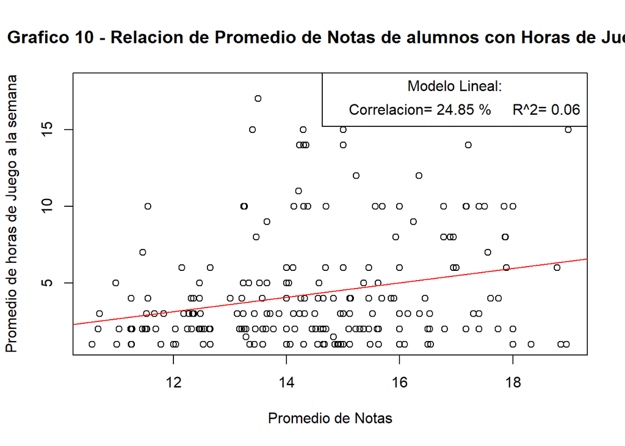

```r
regresion2 <- lm( DDL1_juegan$`Horas de videojuegos` ~ DDL1_juegan$`Promedio ponderado`)

plot(DDL1_juegan$`Promedio ponderado`,DDL1_juegan$`Horas de videojuegos`, ylab = "Promedio de horas de Juego a la semana", xlab = "Promedio de Notas",main="Grafico 10 - Relacion de Promedio de Notas de alumnos con Horas de Juego")
legend("topright",
       legend = c(paste("Correlacion=",round(cor(DDL1_juegan$`Promedio ponderado`,DDL1_juegan$`Horas de videojuegos`)*100,2),"%    ","R^2=",round(cor(DDL1_juegan$`Promedio ponderado`,DDL1_juegan$`Horas de videojuegos`)^2,2))),
       title = "Modelo Lineal:")
abline(regresion2,col='red')
```

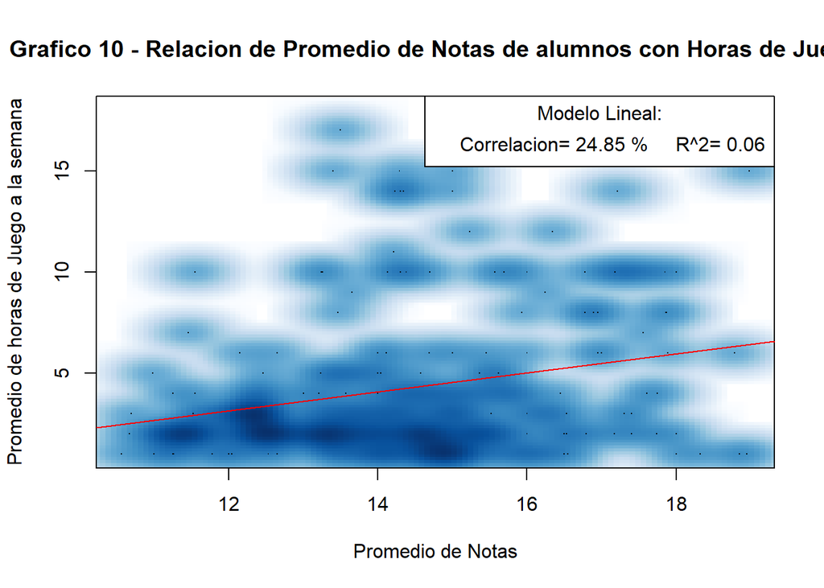

```r
smoothScatter(DDL1_juegan$`Promedio ponderado`,DDL1_juegan$`Horas de videojuegos`, ylab = "Promedio de horas de Juego a la semana", xlab = "Promedio de Notas",main="Grafico 10 - Relacion de Promedio de Notas de alumnos con Horas de Juego")

legend("topright",
       legend = c(paste("Correlacion=",round(cor(DDL1_juegan$`Promedio ponderado`,DDL1_juegan$`Horas de videojuegos`)*100,2),"%    ","R^2=",round(cor(DDL1_juegan$`Promedio ponderado`,DDL1_juegan$`Horas de videojuegos`)^2,2))),
       title = "Modelo Lineal:")
abline(regresion2,col='red')
```

```r
summary(regresion2)
```

```
##
## Call:
## lm(formula = DDL1_juegan$`Horas de videojuegos` ~ DDL1_juegan$`Promedio ponderado`)
##
## Residuals:
##     Min      1Q  Median      3Q     Max
## -5.3930 -2.2862 -0.9192  1.0883 13.1585
##
## Coefficients:
##                                  Estimate Std. Error t value Pr(>|t|)
## (Intercept)                       -2.4786     1.7903  -1.385 0.167610
## DDL1_juegan$`Promedio ponderado`   0.4682     0.1233   3.797 0.000189 ***
## ---
## Signif. codes:  0 '***' 0.001 '**' 0.01 '*' 0.05 '.' 0.1 ' ' 1
##
## Residual standard error: 3.575 on 219 degrees of freedom
## Multiple R-squared:  0.06178,    Adjusted R-squared:  0.05749
## F-statistic: 14.42 on 1 and 219 DF,  p-value: 0.0001894
```

## Variables Aleatorias Discretas

[output not shown]

# **Análisis probabilistico**

## x. Variables aleatorias discretas

En este apartado del informe, se plantearán experimentos aleatorios para explicar el comportamiento de las variables. Se dividirán nuestras variables en aleatorias continuas y discretas, donde también se interpretarán algunas variables categóricas.

### 10.1 Modelo Binomial

#### a) Cantidad de cursos

Proceso de identificación de modelo:

Para su identificación se tomaron en cuenta si la variable “Cantidad de Cursos” ,que identifica la cantidad de cursos que llevan los estudiantes durante el presente ciclo 2022 - 1 ,cumple las consideraciones de la distribución binomial.

*Los experimentos aleatorios posibles con esta variable se pueden repetir n veces con idénticas condiciones.* Los resultados de cada experimento son independientes ,los resultados no afectan la probabilidad de los demás. *La probabilidad de éxito es constante ,no cambia con los experimentos aleatorios.

Cumpliendo las consideraciones ,planteamos la función de probabilidad donde:

X: N° de estudiantes que tienen una cantidad de cursos de la muestra obtenida de nuestra investigación. X~B(n,p) n: La cantidad de ensayos p: La probabilidad de obtener con cantidad de cursos de la muestra

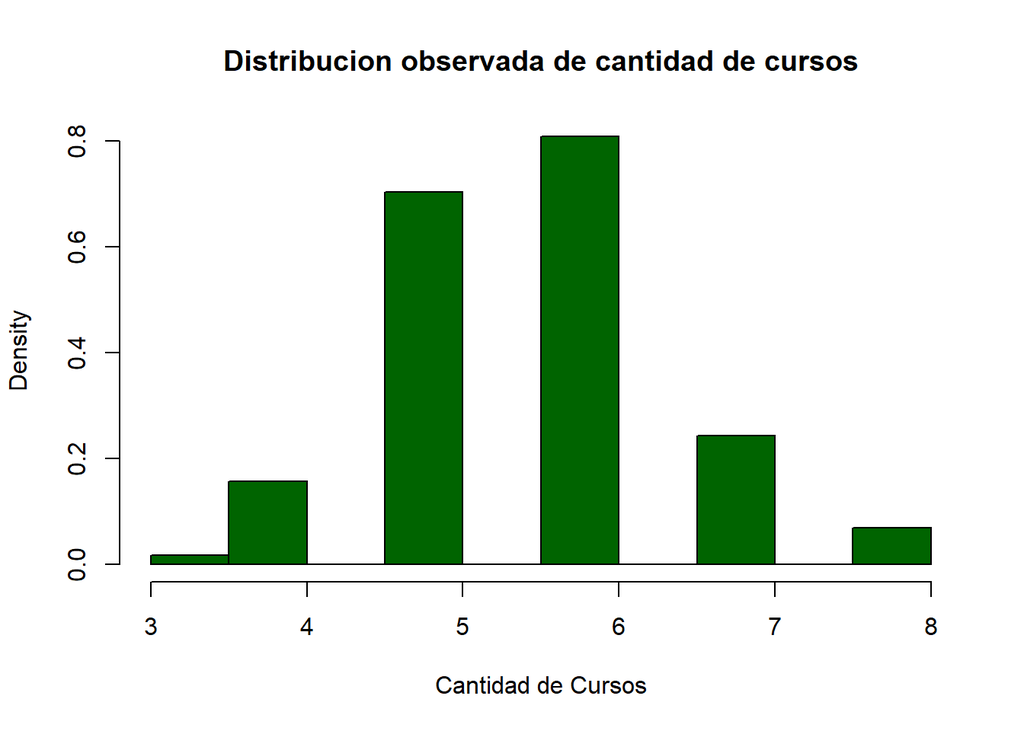

```r
hist(DDL1$`Cantidad de curso`, breaks=10, xlab="Cantidad de Cursos", main = "Distribucion observada de cantidad de cursos", prob = T, col="darkgreen")
```

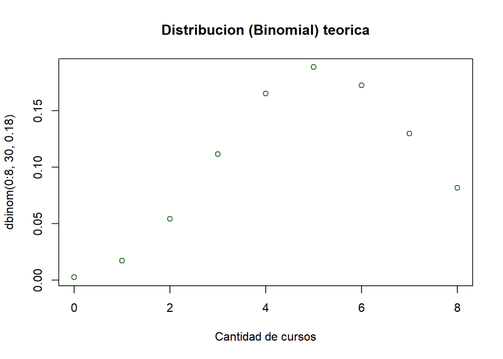

```r
plot(0:8,dbinom(0:8,30,0.18),main = "Distribucion (Binomial) teorica",xlab='Cantidad de cursos',col="darkgreen")
```

#### Caso 1:BINOMIAL

En nuestra investigación, queríamos saber la probabilidad de encontrar menos 50 estudiantes que estén llevando mas de la media de la variable cantidad de cursos (la media seria de 5 cursos de la muestra obtenida de la presente investigación) en el IV y V ciclo, la probabilidad de éxito es de encontrar estudiantes que tengan más de 5 cursos es del 0.55 del presente ciclo 2022 - 1 .

```r
cat("Media de la variable cantidad de curso: ",mean(DDL1_juegan$`Cantidad de curso`),"  ,Tomanos la parte entera de 5 cursos","\n")
```

```
## Media de la variable cantidad de curso:  5.61991   ,Tomanos la parte entera de 5 cursos
```

```r
cat("Cantidad de estudiantes en el IV y V ciclo: ",nrow(filter(DDL1_juegan,Ciclo=="IV"))+nrow(filter(DDL1_juegan,Ciclo=="V"))," estudiantes","\n")
```

```
## Cantidad de estudiantes en el IV y V ciclo:  94  estudiantes
```

```r
cat("Probabilidad de exitos : " , round((nrow(filter(DDL1_juegan,`Cantidad de curso`>5))/nrow(DDL1_juegan)),2))
```

```
## Probabilidad de exitos :  0.55
```

Los parámetros serán :

X: N° de estudiantes que tienen mas de 5 cursos que estén en IV y V ciclo. X~B(n=94,p=0.55) n: La cantidad de estudiantes que están en IV y V. p: La probabilidad de obtener estudiantes que tengan mas de 5 cursos en el presente ciclo 2022-1.

Mosotros queremos saber la probabilidad 50 estudiantes tenga mas de 5 cursos y esten en IV y V ciclo.

P(X<50)

Resultado obtenido:

```r
round(pbinom(50,94,0.55),2)
```

```
## [1] 0.4
```

#### Caso 2: BINOMIAL

```r
cat("Cantidad de alumnos en el IV ciclo: ",nrow(filter(DDL1_juegan,Ciclo=="IV"))," alumnos","\n")
```

```
## Cantidad de alumnos en el IV ciclo:  57  alumnos
```

```r
cat("Probabilidad de que esten llevando 5 cursos matriculados : " , round((nrow(filter(DDL1_juegan,`Cantidad de curso`==6))/nrow(DDL1_juegan)),2))
```

```
## Probabilidad de que esten llevando 5 cursos matriculados :  0.4
```

X~B(n=57,p=0.4)

n: La cantidad de estudiantes que están en IV ciclo. p: La probabilidad de obtener estudiantes que tengan 6 cursos matriculados en el presente ciclo 2022-1.

Nosotros queremos encontrar:

P(20<X<30)=P(X<30)-P(X<20)

Resultado obtenido:

```r
round(pbinom(30,57,0.4)-pbinom(20,57,0.4),2)
```

```
## [1] 0.71
```

Interpretación:

### 10.2 Modelo Geometrico

#### a) cantidad de horas de estudio por dia

Proceso de identificación del modelo:  
Se identificó el modelo geométrico para la variable cantidad de horas de estudio por día. Esta brindara el numero de ensayos hasta el primer caso de éxito, conseguir una persona que estudien 4 horas o más por día.

*El experimento consiste en una serie de ensayos El resultado de cada ensayo se puede clasificar como éxito o fracaso.* Los ensayos son idénticos e independientes *La probabilidad de éxito, p, es la misma de un ensayo a otro.* La variable aleatoria X es el número de ensayos necesarios para obtener el primer éxito

Cumpliendo las consideraciones ,planteamos la función de probabilidad donde:

X: N° de estudiantes que estudian una cantidad de horas por dia de la muestra obtenida de nuestra investigación. X~G(p) p: La probabilidad de obtener estudiantes que estudien una cantidad de horas por día

Para poder demostrar que el modelo es el correcto se gráfica el histograma y se compara con la gráfica teórica del modelo para verificar su validez. Se observa una similitud entre estos.

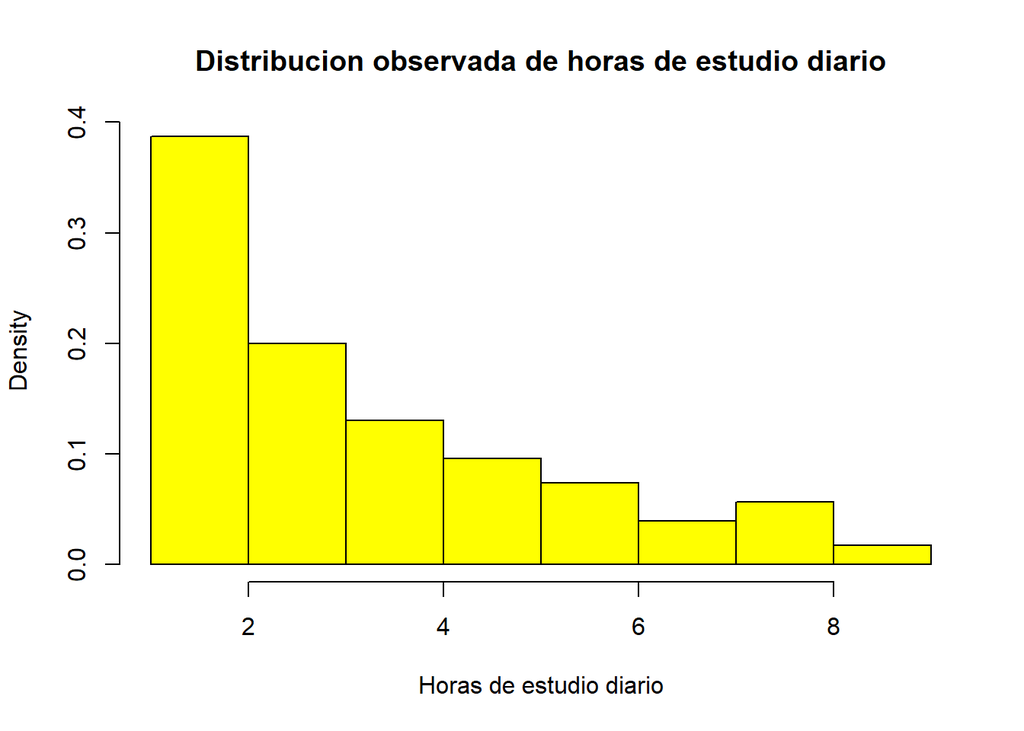

```r
hist (DDL1$`Horas de estudio` ,xlab='Horas de estudio diario', main = 'Distribucion observada de horas de estudio diario', prob = T, col="yellow")
```

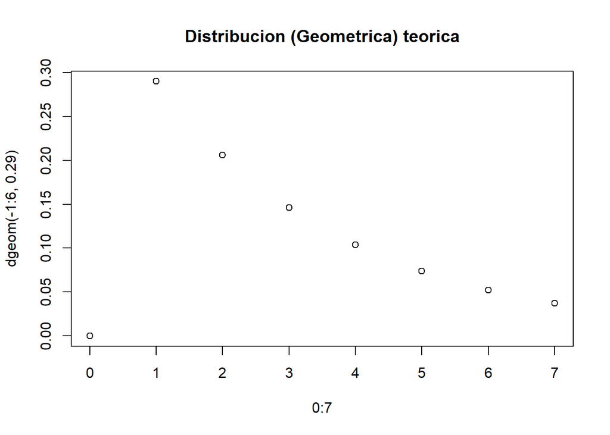

```r
plot(0:7,dgeom(-1:6,0.29), main = 'Distribucion (Geometrica) teorica')
```

#### Caso 3: GEOMETRICO

En nuestra investigación, la probabilidad de encontrar a estudiantes que estudian 4 horas por día es del 13%, nosotros queremos saber cual seria la probabilidad de poder encontrar al primer o cuarto estudiante que estudie de 4 horas a mas en el presente ciclo 2022 - 1.

```r
cat("Probabilidad de encontrar estudiantes que estudien 4 horas o más por día : " , round(nrow(filter(DDL1_juegan,`Horas de estudio`==4))/nrow(DDL1_juegan),2))
```

```
## Probabilidad de encontrar estudiantes que estudien 4 horas o más por día :  0.13
```

X~G(p=0.13)

P(X): Probabilidad de encontrar al menos al primer o cuarto estudiante que estudia de 4 horas por día. Hacemos uso del cuarto axioma de probabilidades,porque cada ensayo es independiente (mutuamente excluyentes):

P(AUB)=P(A)+P(B)

P(X)=P(X=1)+P(X=4)

Los resultados obtenidos:

```r
round(dgeom(1,0.13)+dgeom(4,0.13),2)
```

```
## [1] 0.19
```

Interpretación: Si quisiéramos encontrar la probabilidad de encontrar por primera vez al estudiante que estudie 4 horas al día , en el primer o cuarto estudiante que elijamos al hacer , los resultados obtenidos nos dicen la probabilidad de que esto suceda es del 19% , por lo que no tenemos muchas esperanzas de que encontremos por primera vez a ese estudiante que estudie 4 horas en el primer o cuarto estudiante , por lo que deberíamos buscar en mas estudiantes hasta que tengamos con seguridad que tal estudiante estudia 4 horas diarias.

#### b) Cantidad de horas de videojuego por semana

*El experimento consiste en una serie de ensayos El resultado de cada ensayo se puede clasificar como éxito o fracaso.* Los ensayos son idénticos e independientes *La probabilidad de éxito, p, es la misma de un ensayo a otro.* La variable aleatoria X es el número de ensayos necesarios para obtener el primer éxito

Cumpliendo las consideraciones ,planteamos la función de probabilidad donde:

Para poder demostrar que el modelo es el correcto se gráfica el histograma y se compara con la gráfica teórica del modelo para verificar su validez. Se observa una similitud entre estos.

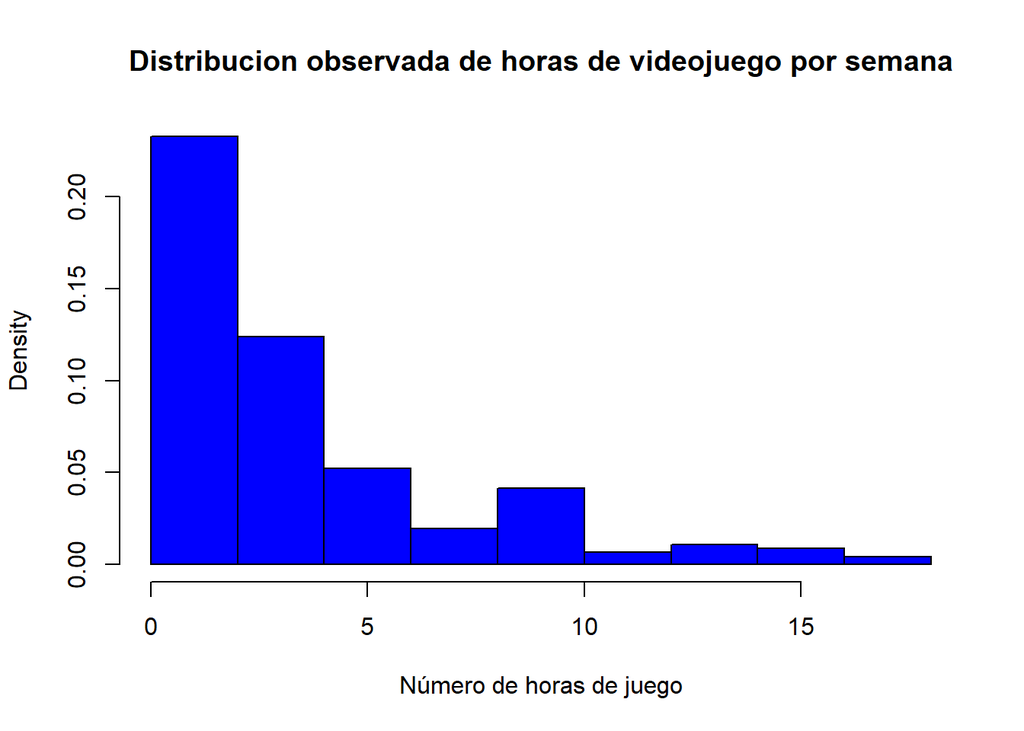

```r
hist(DDL1$`Horas de videojuegos`, main='Distribucion observada de horas de videojuego por semana', xlab = 'Número de horas de juego', prob = TRUE, col="blue")
```

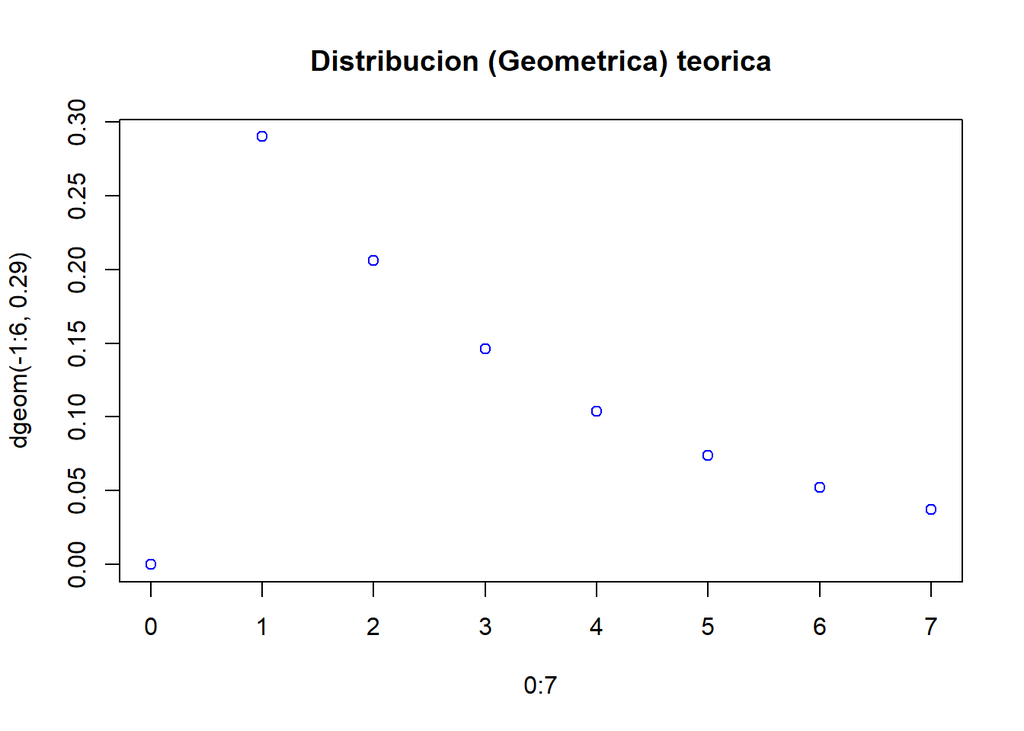

```r
plot(0:7,dgeom(-1:6,0.29), main = 'Distribucion (Geometrica) teorica', col="blue")
```

Cumpliendo las consideraciones ,planteamos la función de probabilidad donde:

#### Caso 4: GEOMETRICO

De nuestra investigación queremos encontrar la probabilidad de que si nosotros escogemos al azar algunos estudiantes , a lo máximo en nuestro décimo estudiante escogido le dedique de 6 a mas horas en videojuegos por semana , si la probabilidad obtener estudiantes que jueguen de 6 a mas horas a los videojuegos por semana es de 24 %.

```r
cat("Probabilidad de encontrar estudiantes que jueguen de 6 horas o más por semana : " , round(nrow(filter(DDL1_juegan,`Horas de videojuegos`>=6))/nrow(DDL1_juegan),2))
```

```
## Probabilidad de encontrar estudiantes que jueguen de 6 horas o más por semana :  0.24
```

X: N° del estudiante que se el primero que muestre que juega 6 horas o más por semana de la muestra obtenida de nuestra investigación.

P(X<=10)

```r
round(pgeom(10,0.24),2)
```

```
## [1] 0.95
```

Interpretación:

El resultado no dice que con una probabilidad del 95% de que podemos encontrar por primera vez aun alumno que juegue mas de 6 horas por semana ,en los 10 alumnos que escogimos al azar.

### 10.3 Modelo Binomial negativa

#### a) Promedio ponderado

*El experimento consiste en una serie de ensayos independientes e idénticos, cada uno con probabilidad p de éxito.* La probabilidad de éxito es constante de un ensayo a otro. *El experimento continúa (se realizan ensayos) hasta obtener exactamente k éxitos.* La variable X es el número de ensayos necesarios para lograr los k éxitos.

Sus parámetros X~ Nbin(Xo - k, k, p)

Donde: Xo = Es el numero de intentos k = Es el numero de casos de éxito p = Es la probabilidad de ocurrencia.

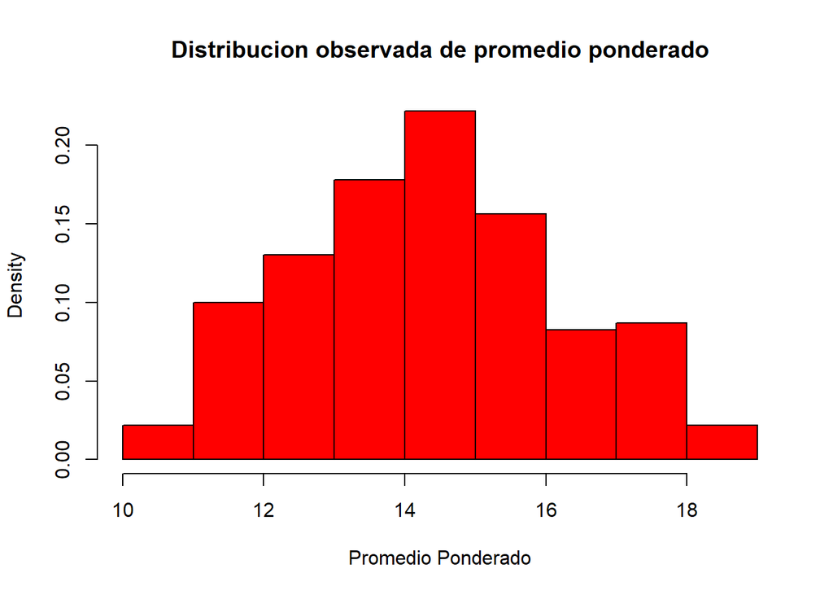

```r
hist(DDL1$`Promedio ponderado`, main='Distribucion observada de promedio ponderado', xlab = 'Promedio Ponderado', prob = TRUE, col="red")
```

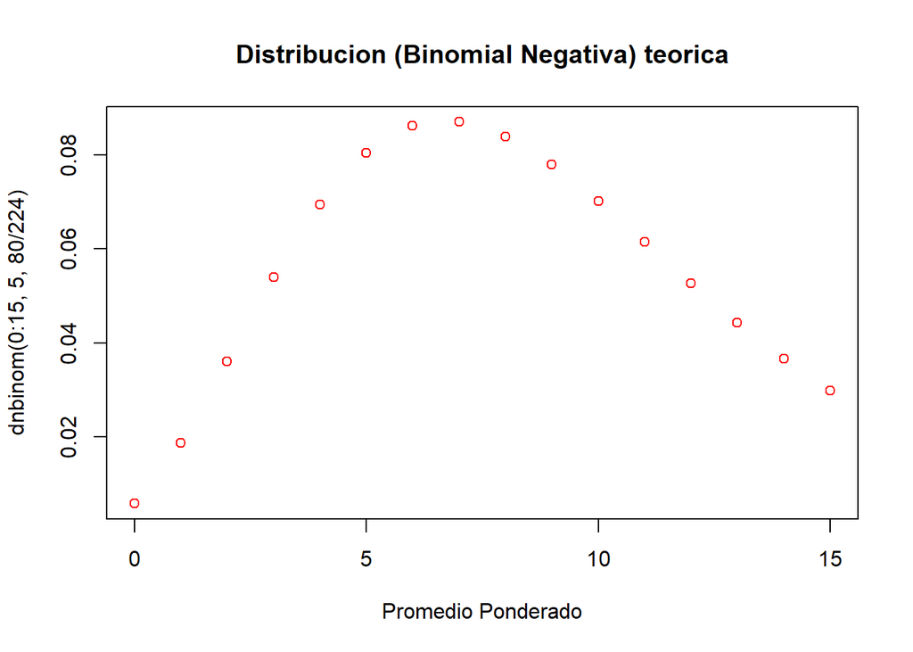

```r
plot(0:15,dnbinom(0:15,5,80/224),xlab='Promedio Ponderado',main = 'Distribucion (Binomial Negativa) teorica', col="red")
```

#### Caso 5: BINOMIAL NEGATIVA

De manera que los universitarios que tienen un promedio mayor e igual a 15 ,estudiantes que tienen un buen rendimiento académico. Por tal motivo, conoceremos la probabilidad de encontrar 5 estudiantes universitarios que un promedio mayor e igual a 15 que estén en II ciclo académico.

```r
cat("Cantidad de estudiantes en el II ciclo: ",nrow(filter(DDL1_juegan,Ciclo=="II")),"estudiantes","\n")
```

```
## Cantidad de estudiantes en el II ciclo:  25 estudiantes
```

```r
cat("Probabilidad de encontrar a los estudiantes que tengan un promedio mayor e igual a 15 : " , round(nrow(filter(DDL1_juegan,`Promedio ponderado`>=15))/nrow(DDL1_juegan),2))
```

```
## Probabilidad de encontrar a los estudiantes que tengan un promedio mayor e igual a 15 :  0.37
```

X: N° del estudiantes hasta encontrar a los 5 estudiantes universitarios que tengan un promedio mayor e igual a 15.

Sus parámetros: X~ Nbin(k=5, p=0.37)

k: Los 5 estudiantes universitarios que tengan un promedio mayor e igual a 15. p: Probabilidad de encontrar a los estudiantes que tengan un promedio mayor e igual a 15.

P(X=25)

```r
round(dnbinom(25-5,5,0.37),2)
```

```
## [1] 0.01
```

Interpretación: Los estudiantes que tiene un mejor rendimiento académico y que tengan un promedio mayor e igual a 15,la posibilidad de encontrar 5 de ellos que estén en II ciclo académico , porque obtuvimos una probabilidad del 1% de lograr encontrar a esos 5 estudiantes.

#### Caso 6: BINOMIAL NEGATIVA

En nuestra investigación, encontramos que la mayor cantidad de estudiantes que respondieron nuestra encuesta fueron estudiantes varones a comparación de las mujeres que también juegas videojuegos en su ratos libres, porque lo queremos encontrar el probabilidad de encontrar 10 estudiantes mujeres que tengan un promedio mayor a 14 , que estén en II o V ciclo académico dentro la base de datos obtenida de nuestra investigación.

```r
cat("Cantidad de alumnas en el II ciclo: ",nrow(filter(DDL1_juegan,Ciclo=="II" & Género=="Mujer") ),"alumnos","\n")
```

```
## Cantidad de alumnas en el II ciclo:  13 alumnos
```

```r
cat("Cantidad de alumnas en el V ciclo: ",nrow(filter(DDL1_juegan,Ciclo=="V" & Género=="Mujer") ),"alumnos","\n")
```

```
## Cantidad de alumnas en el V ciclo:  18 alumnos
```

```r
cat("Probabilidad de encontrar a los estudiantes que tengan un promedio mayor a 14 : " , round(nrow(filter(DDL1_juegan,`Promedio ponderado`>14 ))/nrow(DDL1_juegan),2))
```

```
## Probabilidad de encontrar a los estudiantes que tengan un promedio mayor a 14 :  0.56
```

X: N° de estudiantes mujeres hasta encontrar a 10 estudiantes universitarias que tengan un promedio mayor a 14 .

k: Las 10 estudiantes universitarias que tengan un promedio mayor a 14 . p: Probabilidad de encontrar a las estudiantes que tengan un promedio mayor a 14 .

```r
round(pnbinom(13-10,10,0.56)+pnbinom(18-10,10,0.56),2)
```

```
## [1] 0.72
```

Interpretación: La probabilidad de encontrar 10 alumnas que tengan un promedio mayor a 14 en el II o V ciclo es del 72% , es una probabilidad buena de poder encontrar estudiantes mujeres que tengan dicho promedio.

### XI. Tablas Probabilisticas:

#### 11.1 TABLA DE GÉNERO VS DEPENDENCIA

```r
library(car)
library(readr)
```

```r
cuadro_genero_vs_dependencia<-data.frame(
  Genero=c("Femenino"," Masculino","Total"),

  Nunca=c(nrow(filter(DDL1_juegan,Género=="Mujer"&Dependencia=="nunca")),
          nrow(filter(DDL1_juegan,Género=="Hombre"&Dependencia=="nunca")),
          nrow(filter(DDL1_juegan,Género=="Mujer"&Dependencia=="nunca"))+nrow(filter(DDL1_juegan,Género=="Hombre"&Dependencia=="nunca"))
          ),

  Algunas_veces=c(nrow(filter(DDL1_juegan,Género=="Mujer"&Dependencia=="algunas veces")),
                  nrow(filter(DDL1_juegan,Género=="Hombre"&Dependencia=="algunas veces")),
                  nrow(filter(DDL1_juegan,Género=="Mujer"&Dependencia=="algunas veces"))+nrow(filter(DDL1_juegan,Género=="Hombre"&Dependencia=="algunas veces"))
                  ),

  Rara_vez=c(nrow(filter(DDL1_juegan,Género=="Mujer"&Dependencia=="rara vez")),
             nrow(filter(DDL1_juegan,Género=="Hombre"&Dependencia=="rara vez")),
             nrow(filter(DDL1_juegan,Género=="Mujer"&Dependencia=="rara vez"))+nrow(filter(DDL1_juegan,Género=="Hombre"&Dependencia=="rara vez"))
             ),

  Siempre=c(nrow(filter(DDL1_juegan,Género=="Mujer"&Dependencia=="siempre")),
            nrow(filter(DDL1_juegan,Género=="Hombre"&Dependencia=="siempre")),
            nrow(filter(DDL1_juegan,Género=="Mujer"&Dependencia=="siempre"))+nrow(filter(DDL1_juegan,Género=="Hombre"&Dependencia=="siempre"))
            ),

  Con_frecuencia=c(nrow(filter(DDL1_juegan,Género=="Mujer"&Dependencia=="con frecuencia")),
                   nrow(filter(DDL1_juegan,Género=="Hombre"&Dependencia=="con frecuencia")),
                   nrow(filter(DDL1_juegan,Género=="Mujer"&Dependencia=="con frecuencia"))+nrow(filter(DDL1_juegan,Género=="Hombre"&Dependencia=="con frecuencia"))
                   ),

  Total=c(
    nrow(filter(DDL1_juegan,Género=="Mujer")),
    nrow(filter(DDL1_juegan,Género=="Hombre")),
    nrow(filter(DDL1_juegan,Género=="Mujer"))+nrow(filter(DDL1_juegan,Género=="Hombre"))
  )

)
```

#### TABLA 1 - TABLA DE GÉNERO VS DEPENDENCIA

```r
cuadro_genero_vs_dependencia
```

| Genero | Nunca | Algunas_veces | Rara_vez | Siempre | Con_frecuencia | Total |
| --- | --- | --- | --- | --- | --- | --- |
| Femenino | 44 | 21 | 32 | 2 | 2 | 101 |
| Masculino | 50 | 19 | 36 | 4 | 11 | 120 |
| Total | 94 | 40 | 68 | 6 | 13 | 221 |

#### Probabilidad 1:

Hallar la probabilidad de encontrar un estudiante que halla marcado que *algunas veces* siente una dependencia hacia los videojuegos tanto un estudiante femenino

AXIOMA 3 P(AUB)= P(A) + P(B) - P(A∩B)

```r
#P(AUB)= P(A) + P(B)
round( (101/221) + (40/221) - (21/221),2)
```

```
## [1] 0.54
```

#### 11.2 TABLA DE PLATAFORMA VS TIPO DE JUEGO

```r
cuadro_plataforma_vs_tipo_de_juego<-data.frame(
  Plataforma=c("Pc","Tablet","Movil","Consolas","Total"),
  Estrategia=c(
    nrow(filter(DDL1_juegan,Plataforma=="Pc"  & `Area de juego`=="Estrategia")),
    nrow(filter(DDL1_juegan,Plataforma=="Tablet"  & `Area de juego`=="Estrategia")),
    nrow(filter(DDL1_juegan,Plataforma=="Movil"  & `Area de juego`=="Estrategia")),
    nrow(filter(DDL1_juegan,Plataforma=="Consola (PSP , Xbox ,etc)" & `Area de juego`=="Estrategia")),
    nrow(filter(DDL1_juegan,Plataforma=="Pc"  & `Area de juego`=="Estrategia"))+
    nrow(filter(DDL1_juegan,Plataforma=="Tablet"  & `Area de juego`=="Estrategia"))+
    nrow(filter(DDL1_juegan,Plataforma=="Movil"  & `Area de juego`=="Estrategia"))+
    nrow(filter(DDL1_juegan,Plataforma=="Consola (PSP , Xbox ,etc)" & `Area de juego`=="Estrategia"))
  ),
  Disparos=c(
    nrow(filter(DDL1_juegan,Plataforma=="Pc"  & `Area de juego`=="Disparos")),
    nrow(filter(DDL1_juegan,Plataforma=="Tablet"  & `Area de juego`=="Disparos")),
    nrow(filter(DDL1_juegan,Plataforma=="Movil"  & `Area de juego`=="Disparos")),
    nrow(filter(DDL1_juegan,Plataforma=="Consola (PSP , Xbox ,etc)" & `Area de juego`=="Disparos")),
        nrow(filter(DDL1_juegan,Plataforma=="Pc"  & `Area de juego`=="Disparos"))+
    nrow(filter(DDL1_juegan,Plataforma=="Tablet"  & `Area de juego`=="Disparos"))+
    nrow(filter(DDL1_juegan,Plataforma=="Movil"  & `Area de juego`=="Disparos"))+
    nrow(filter(DDL1_juegan,Plataforma=="Consola (PSP , Xbox ,etc)" & `Area de juego`=="Disparos"))
  ),
  Deportes=c(
    nrow(filter(DDL1_juegan,Plataforma=="Pc"  & `Area de juego`=="Deportivos")),
    nrow(filter(DDL1_juegan,Plataforma=="Tablet"  & `Area de juego`=="Deportivos")),
    nrow(filter(DDL1_juegan,Plataforma=="Movil"  & `Area de juego`=="Deportivos")),
    nrow(filter(DDL1_juegan,Plataforma=="Consola (PSP , Xbox ,etc)" & `Area de juego`=="Deportivos")),
        nrow(filter(DDL1_juegan,Plataforma=="Pc"  & `Area de juego`=="Deportivos"))+
    nrow(filter(DDL1_juegan,Plataforma=="Tablet"  & `Area de juego`=="Deportivos"))+
    nrow(filter(DDL1_juegan,Plataforma=="Movil"  & `Area de juego`=="Deportivos"))+
    nrow(filter(DDL1_juegan,Plataforma=="Consola (PSP , Xbox ,etc)" & `Area de juego`=="Deportivos"))
  ),
  Lucha=c(
    nrow(filter(DDL1_juegan,Plataforma=="Pc"  & `Area de juego`=="Lucha")),
    nrow(filter(DDL1_juegan,Plataforma=="Tablet"  & `Area de juego`=="Lucha")),
    nrow(filter(DDL1_juegan,Plataforma=="Movil"  & `Area de juego`=="Lucha")),
    nrow(filter(DDL1_juegan,Plataforma=="Consola (PSP , Xbox ,etc)" & `Area de juego`=="Lucha")),
        nrow(filter(DDL1_juegan,Plataforma=="Pc"  & `Area de juego`=="Lucha"))+
    nrow(filter(DDL1_juegan,Plataforma=="Tablet"  & `Area de juego`=="Lucha"))+
    nrow(filter(DDL1_juegan,Plataforma=="Movil"  & `Area de juego`=="Lucha"))+
    nrow(filter(DDL1_juegan,Plataforma=="Consola (PSP , Xbox ,etc)" & `Area de juego`=="Lucha"))
  ),
  Arcade=c(
    nrow(filter(DDL1_juegan,Plataforma=="Pc"  & `Area de juego`=="Arcade")),
    nrow(filter(DDL1_juegan,Plataforma=="Tablet"  & `Area de juego`=="Arcade")),
    nrow(filter(DDL1_juegan,Plataforma=="Movil"  & `Area de juego`=="Arcade")),
    nrow(filter(DDL1_juegan,Plataforma=="Consola (PSP , Xbox ,etc)" & `Area de juego`=="Arcade")),
        nrow(filter(DDL1_juegan,Plataforma=="Pc"  & `Area de juego`=="Arcade"))+
    nrow(filter(DDL1_juegan,Plataforma=="Tablet"  & `Area de juego`=="Arcade"))+
    nrow(filter(DDL1_juegan,Plataforma=="Movil"  & `Area de juego`=="Arcade"))+
    nrow(filter(DDL1_juegan,Plataforma=="Consola (PSP , Xbox ,etc)" & `Area de juego`=="Arcade"))
  ),
  Simuladores=c(
    nrow(filter(DDL1_juegan,Plataforma=="Pc"  & `Area de juego`=="Simuladores")),
    nrow(filter(DDL1_juegan,Plataforma=="Tablet"  & `Area de juego`=="Simuladores")),
    nrow(filter(DDL1_juegan,Plataforma=="Movil"  & `Area de juego`=="Simuladores")),
    nrow(filter(DDL1_juegan,Plataforma=="Consola (PSP , Xbox ,etc)" & `Area de juego`=="Simuladores")),
        nrow(filter(DDL1_juegan,Plataforma=="Pc"  & `Area de juego`=="Simuladores"))+
    nrow(filter(DDL1_juegan,Plataforma=="Tablet"  & `Area de juego`=="Simuladores"))+
    nrow(filter(DDL1_juegan,Plataforma=="Movil"  & `Area de juego`=="Simuladores"))+
    nrow(filter(DDL1_juegan,Plataforma=="Consola (PSP , Xbox ,etc)" & `Area de juego`=="Simuladores"))

  ),
  Otros=c(
    nrow(filter(DDL1_juegan,Plataforma=="Pc"  & `Area de juego`=="Otros" )),
    nrow(filter(DDL1_juegan,Plataforma=="Tablet"  & `Area de juego`=="Otros" )),
    nrow(filter(DDL1_juegan,Plataforma=="Movil"  & `Area de juego`=="Otros" )),
    nrow(filter(DDL1_juegan,Plataforma=="Consola (PSP , Xbox ,etc)" & `Area de juego`=="Otros" )),
    nrow(filter(DDL1_juegan,Plataforma=="Pc"  & `Area de juego`=="Otros" ))+
    nrow(filter(DDL1_juegan,Plataforma=="Tablet"  & `Area de juego`=="Otros" ))+
    nrow(filter(DDL1_juegan,Plataforma=="Movil"  & `Area de juego`=="Otros" ))+
    nrow(filter(DDL1_juegan,Plataforma=="Consola (PSP , Xbox ,etc)" & `Area de juego`=="Otros" ))
  ),
  Total=c(
    nrow(filter(DDL1_juegan,Plataforma=="Pc"  )),
    nrow(filter(DDL1_juegan,Plataforma=="Tablet" )),
    nrow(filter(DDL1_juegan,Plataforma=="Movil" )),
    nrow(filter(DDL1_juegan,Plataforma=="Consola (PSP , Xbox ,etc)"  )),
    nrow(filter(DDL1_juegan,Plataforma=="Pc"  ))+
    nrow(filter(DDL1_juegan,Plataforma=="Tablet" ))+
    nrow(filter(DDL1_juegan,Plataforma=="Movil" ))+
    nrow(filter(DDL1_juegan,Plataforma=="Consola (PSP , Xbox ,etc)"  ))
  )

)
```

#### TABLA 2 - TABLA DE PLATAFORMA VS TIPO DE JUEGO

```r
cuadro_plataforma_vs_tipo_de_juego
```

| Plataforma | Estrategia | Disparos | Deportes | Lucha | Arcade | Simuladores | Otros | Total |
| --- | --- | --- | --- | --- | --- | --- | --- | --- |
| Pc | 30 | 20 | 3 | 14 | 10 | 2 | 10 | 89 |
| Tablet | 2 | 0 | 1 | 1 | 5 | 0 | 1 | 10 |
| Movil | 23 | 16 | 8 | 9 | 9 | 5 | 8 | 78 |
| Consolas | 15 | 13 | 7 | 1 | 1 | 3 | 4 | 44 |
| Total | 70 | 49 | 19 | 25 | 25 | 10 | 23 | 221 |

#### Probabilidad 2:

Calcular la probabilidad de encontrar un estudiante que juegue en la plataforma PC pero que no juegue la categoría lucha

AXIOMA 5 P(A∩B) = P(A) - P(A∩B)

```r
round((89/221)-(14/221),2)
```

```
## [1] 0.34
```

#### 11.3 TABLA DE CARRERA VS CURSO DESAPROBADO

```r
cuadro_carrera_vs_curso_desaprobado<-data.frame(
 Aprobado=c("Si","No","Total"),
 Ingenieria_Civil=c(
   nrow(filter(DDL1_juegan,`Curso Desaprobado`=="Sí" & Carrera=="Ingeniería Civil")),
   nrow(filter(DDL1_juegan,`Curso Desaprobado`=="No" & Carrera=="Ingeniería Civil")),
   nrow(filter(DDL1_juegan,`Curso Desaprobado`=="Sí" & Carrera=="Ingeniería Civil"))+
   nrow(filter(DDL1_juegan,`Curso Desaprobado`=="No" & Carrera=="Ingeniería Civil"))
 ),
 Ingenieria_Mecatronico=c(
   nrow(filter(DDL1_juegan,`Curso Desaprobado`=="Sí" & Carrera=="Ingeniería Mecatrónica" )),
   nrow(filter(DDL1_juegan,`Curso Desaprobado`=="No" & Carrera=="Ingeniería Mecatrónica" )),
   nrow(filter(DDL1_juegan,`Curso Desaprobado`=="Sí" & Carrera=="Ingeniería Mecatrónica" ))+
   nrow(filter(DDL1_juegan,`Curso Desaprobado`=="No" & Carrera=="Ingeniería Mecatrónica" ))
 ),
 Ingenieria_Mecanica=c(
   nrow(filter(DDL1_juegan,`Curso Desaprobado`=="Sí" & Carrera=="Ingeniería Mecánica")),
   nrow(filter(DDL1_juegan,`Curso Desaprobado`=="No" & Carrera=="Ingeniería Mecánica")),
   nrow(filter(DDL1_juegan,`Curso Desaprobado`=="Sí" & Carrera=="Ingeniería Mecánica"))+
   nrow(filter(DDL1_juegan,`Curso Desaprobado`=="No" & Carrera=="Ingeniería Mecánica"))
 ),
 Ingenieria_Industrial=c(
   nrow(filter(DDL1_juegan,`Curso Desaprobado`=="Sí" & Carrera=="Ingeniería Industrial")),
   nrow(filter(DDL1_juegan,`Curso Desaprobado`=="No" & Carrera=="Ingeniería Industrial")),
   nrow(filter(DDL1_juegan,`Curso Desaprobado`=="Sí" & Carrera=="Ingeniería Industrial"))+
   nrow(filter(DDL1_juegan,`Curso Desaprobado`=="No" & Carrera=="Ingeniería Industrial"))
 ),
 Ingenieria_Electronica=c(
   nrow(filter(DDL1_juegan,`Curso Desaprobado`=="Sí" & Carrera=="Ingeniería Electrónica")),
   nrow(filter(DDL1_juegan,`Curso Desaprobado`=="No" & Carrera=="Ingeniería Electrónica")),
   nrow(filter(DDL1_juegan,`Curso Desaprobado`=="Sí" & Carrera=="Ingeniería Electrónica"))+
   nrow(filter(DDL1_juegan,`Curso Desaprobado`=="No" & Carrera=="Ingeniería Electrónica"))
 ),
 Ingenieria_Quimica=c(
   nrow(filter(DDL1_juegan,`Curso Desaprobado`=="Sí" & Carrera=="Ingeniería Química")),
   nrow(filter(DDL1_juegan,`Curso Desaprobado`=="No" & Carrera=="Ingeniería Química")),
   nrow(filter(DDL1_juegan,`Curso Desaprobado`=="Sí" & Carrera=="Ingeniería Química"))+
   nrow(filter(DDL1_juegan,`Curso Desaprobado`=="No" & Carrera=="Ingeniería Química"))
 ),
 Ingenieria_Ambiental=c(
   nrow(filter(DDL1_juegan,`Curso Desaprobado`=="Sí" & Carrera=="Ingeniería Ambiental")),
   nrow(filter(DDL1_juegan,`Curso Desaprobado`=="No" & Carrera=="Ingeniería Ambiental")),
   nrow(filter(DDL1_juegan,`Curso Desaprobado`=="Sí" & Carrera=="Ingeniería Ambiental"))+
   nrow(filter(DDL1_juegan,`Curso Desaprobado`=="No" & Carrera=="Ingeniería Ambiental"))
 ),
 Ingenieria_de_la_Energia=c(
   nrow(filter(DDL1_juegan,`Curso Desaprobado`=="Sí" & Carrera=="Ingeniería de la Energía")),
   nrow(filter(DDL1_juegan,`Curso Desaprobado`=="No" & Carrera=="Ingeniería de la Energía")),
   nrow(filter(DDL1_juegan,`Curso Desaprobado`=="Sí" & Carrera=="Ingeniería de la Energía"))+
   nrow(filter(DDL1_juegan,`Curso Desaprobado`=="No" & Carrera=="Ingeniería de la Energía"))
 ),
 Bioingenieria=c(
   nrow(filter(DDL1_juegan,`Curso Desaprobado`=="Sí" & Carrera=="Bioingeniería"    )),
   nrow(filter(DDL1_juegan,`Curso Desaprobado`=="No" & Carrera=="Bioingeniería"    )),
   nrow(filter(DDL1_juegan,`Curso Desaprobado`=="Sí" & Carrera=="Bioingeniería"    ))+
   nrow(filter(DDL1_juegan,`Curso Desaprobado`=="No" & Carrera=="Bioingeniería"    ))
 ),
 Ciencias_de_la_computacion=c(
   nrow(filter(DDL1_juegan,`Curso Desaprobado`=="Sí" & Carrera=="Ciencias de la Computación")),
   nrow(filter(DDL1_juegan,`Curso Desaprobado`=="No" & Carrera=="Ciencias de la Computación")),
   nrow(filter(DDL1_juegan,`Curso Desaprobado`=="Sí" & Carrera=="Ciencias de la Computación"))+
   nrow(filter(DDL1_juegan,`Curso Desaprobado`=="No" & Carrera=="Ciencias de la Computación"))
 ),
 Ciencia_de_Datos=c(
   nrow(filter(DDL1_juegan,`Curso Desaprobado`=="Sí" & Carrera=="Ciencias de Datos")),
   nrow(filter(DDL1_juegan,`Curso Desaprobado`=="No" & Carrera=="Ciencias de Datos")),
   nrow(filter(DDL1_juegan,`Curso Desaprobado`=="Sí" & Carrera=="Ciencias de Datos"))+
   nrow(filter(DDL1_juegan,`Curso Desaprobado`=="No" & Carrera=="Ciencias de Datos"))
 ),
 Administración_de_Negocios_Digitales=c(
   nrow(filter(DDL1_juegan,`Curso Desaprobado`=="Sí" & Carrera=="Administración de Negocios Digitales")),
   nrow(filter(DDL1_juegan,`Curso Desaprobado`=="No" & Carrera=="Administración de Negocios Digitales")),
   nrow(filter(DDL1_juegan,`Curso Desaprobado`=="Sí" & Carrera=="Administración de Negocios Digitales"))+
   nrow(filter(DDL1_juegan,`Curso Desaprobado`=="No" & Carrera=="Administración de Negocios Digitales"))
 ),
 Total=c(
   nrow(filter(DDL1_juegan,`Curso Desaprobado`=="Sí" )),
   nrow(filter(DDL1_juegan,`Curso Desaprobado`=="No")),
   nrow(filter(DDL1_juegan,`Curso Desaprobado`=="Sí" ))+
   nrow(filter(DDL1_juegan,`Curso Desaprobado`=="No"))
 )
)
```

#### TABLA 3 - TABLA DE CARRERA VS CURSO DESAPROBADO

```r
cuadro_carrera_vs_curso_desaprobado
```

| Aprobado | Ingenieria_Civil | Ingenieria_Mecatronico | Ingenieria_Mecanica | Ingenieria_Industrial | Ingenieria_Electronica | Ingenieria_Quimica | Ingenieria_Ambiental | Ingenieria_de_la_Energia | Bioingenieria | Ciencias_de_la_computacion | Ciencia_de_Datos | Administración_de_Negocios_Digitales | Total |
| --- | --- | --- | --- | --- | --- | --- | --- | --- | --- | --- | --- | --- | --- |
| Si | 10 | 8 | 8 | 13 | 8 | 5 | 8 | 11 | 9 | 10 | 8 | 5 | 103 |
| No | 12 | 11 | 6 | 8 | 11 | 6 | 10 | 6 | 14 | 20 | 10 | 4 | 118 |
| Total | 22 | 19 | 14 | 21 | 19 | 11 | 18 | 17 | 23 | 30 | 18 | 9 | 221 |

#### Probabilidad 3:

Calcular la probabilidad de encontrar estudiantes que hayan desaprobado un curso, sabiendo que deben de ser de la carrera de Ciencias de la Computación.

AXIOMA 9: P(A/B)= P(A∩B)/P(B)

```r
round((10/221)/(30/221),2)
```

```
## [1] 0.33
```

Concluimos: La probabilidad de encontrar un estudiante de halla desaprobado curso, sabiendo que es de la carrera de Ciencias de la computación es de 33%

#### 11.4 TABLA DE MODO DE JUEGO Y RAZÓN DE JUGAR

```r
cuadro_Mode_de_juego_vs_Razon_de_jugar<-data.frame(
  Modo_de_Juego=c("Solo","Multijugador","Total"),
  Ocio=c(
    nrow(filter(DDL1_juegan,`Modo de Jugar`=="Solo(a)" & `Razon de Jugar`=="Ocio")),
    nrow(filter(DDL1_juegan,`Modo de Jugar`=="Amigos" & `Razon de Jugar`=="Ocio")),
    nrow(filter(DDL1_juegan,`Modo de Jugar`=="Solo(a)" & `Razon de Jugar`=="Ocio"))+
    nrow(filter(DDL1_juegan,`Modo de Jugar`=="Amigos" & `Razon de Jugar`=="Ocio"))
  ),
  Relajacion=c(
    nrow(filter(DDL1_juegan,`Modo de Jugar`=="Solo(a)" & `Razon de Jugar`=="Relajación")),
    nrow(filter(DDL1_juegan,`Modo de Jugar`=="Amigos" & `Razon de Jugar`=="Relajación")),
    nrow(filter(DDL1_juegan,`Modo de Jugar`=="Solo(a)" & `Razon de Jugar`=="Relajación"))+
    nrow(filter(DDL1_juegan,`Modo de Jugar`=="Amigos" & `Razon de Jugar`=="Relajación"))
  ),
  Amistades=c(
    nrow(filter(DDL1_juegan,`Modo de Jugar`=="Solo(a)" & `Razon de Jugar`=="Amigos")),
    nrow(filter(DDL1_juegan,`Modo de Jugar`=="Amigos" & `Razon de Jugar`=="Amigos")),
    nrow(filter(DDL1_juegan,`Modo de Jugar`=="Solo(a)" & `Razon de Jugar`=="Amigos"))+
    nrow(filter(DDL1_juegan,`Modo de Jugar`=="Amigos" & `Razon de Jugar`=="Amigos"))
  ),
  Competicion=c(
    nrow(filter(DDL1_juegan,`Modo de Jugar`=="Solo(a)" & `Razon de Jugar`=="Competición")),
    nrow(filter(DDL1_juegan,`Modo de Jugar`=="Amigos" & `Razon de Jugar`=="Competición")),
    nrow(filter(DDL1_juegan,`Modo de Jugar`=="Solo(a)" & `Razon de Jugar`=="Competición"))+
    nrow(filter(DDL1_juegan,`Modo de Jugar`=="Amigos" & `Razon de Jugar`=="Competición"))
  ),
  Otros=c(
    nrow(filter(DDL1_juegan,`Modo de Jugar`=="Solo(a)" & `Razon de Jugar`=="Otro")),
    nrow(filter(DDL1_juegan,`Modo de Jugar`=="Amigos" & `Razon de Jugar`=="Otro")),
    nrow(filter(DDL1_juegan,`Modo de Jugar`=="Solo(a)" & `Razon de Jugar`=="Otro"))+
    nrow(filter(DDL1_juegan,`Modo de Jugar`=="Amigos" & `Razon de Jugar`=="Otro"))
  ),
  Total=c(
    nrow(filter(DDL1_juegan,`Modo de Jugar`=="Solo(a)" )),
    nrow(filter(DDL1_juegan,`Modo de Jugar`=="Amigos" )),
    nrow(filter(DDL1_juegan,`Modo de Jugar`=="Solo(a)" ))+
    nrow(filter(DDL1_juegan,`Modo de Jugar`=="Amigos" ))
  )
)
```

#### TABLA 4 - TABLA DE MODO DE JUEGO Y RAZÓN DE JUGAR

```r
cuadro_Mode_de_juego_vs_Razon_de_jugar
```

| Modo_de_Juego | Ocio | Relajacion | Amistades | Competicion | Otros | Total |
| --- | --- | --- | --- | --- | --- | --- |
| Solo | 32 | 40 | 7 | 28 | 1 | 127 |
| Multijugador | 21 | 27 | 22 | 21 | 0 | 94 |
| Total | 53 | 67 | 29 | 49 | 1 | 221 |

#### Probabilidad 4:

Calcular la probabilidad de encontrar estudiantes que no jueguen en multijugador, ni que jueguen por relajación

AXIOMA 7: P(A^C ∩ B^C) = 1- P(AUB)

```r
round((1 - ((94/221)+(67/221))),2)
```

```
## [1] 0.27
```

### XII. Conclusiones:

-Las estimaciones probabilísticas que obtuvimos de la parte de modelamiento y uso de axiomas nos ayudo a poder afianzar los conocimientos obtenidos en las clases y a su vez para poder ver las diversas relaciones que existían entre las variables de ¨X¨ y ¨Y¨ en sus respectivas tablas. Una que en particular no ayudo a poder concluir con algo certero fue la del genero del juego y de la dependencia, en esta parte, aparte del caso presentado en el informe, jugando con los datos, pudimos ver que el juego mas jugado y el que mas dependencia daba eran los juegos de estrategia. Con esto podríamos concluir que los juegos de estrategia son los que mas ayudan a desarrollar y relajar las mentes de los estudiantes de la universidad independientemente de las carreras y del genero.

### Referencias Bibliograficas

1. Albán y Calero, El rendimiento académico: Aproximación necesaria a un problema pedagógico actual (2017). ANDINA, Consumo de videojuegos en el Perú creció durante la pandemia (6 set 2021) Consultado 17 oct 2021. Disponible en: https://andina.pe/agencia/noticia-consumo-videojuegos-el-peru-crecio-durante-pandemia-859350.aspx
2. Belli, S. y López R., C. (2008) Breve historia de los videojuegos. Athenea Digital, Revista de Pensamiento e Investigación Social. 14, 159-179. Recuperado de: https://www.redalyc.org/pdf/537/53701409.pdf Boris, Síntomas de la abstinencia a los videojuegos, RECAL (2020) Consultado 18 oct 2021. Disponible en: https://www.fundacionrecal.org/adiccion-tecnologia/sintomas-de-abstinencia-a-los-videojuegos/
3. Carbonell, X. (2014). La adicción a los videojuegos en el DSM-5. adicciones, 26(2), 91-95.Disponible en: https://www.redalyc.org/pdf/2891/289131590001.pdf Carbonell, X., Talarn Caparrós, A., Beranuy Fargues, M., Oberst, U., & Graner, C. (2009). Cuando jugar se convierte en un problema: el juego patológico y la adicción a los juegos de rol online. Aloma, 2009, Núm. 25. Extraído de: https://recerca.blanquerna.edu/conductes-desadaptatives/wp-content/uploads/2013/06/cuando-jugar-se-convierte-en-un-problema.pdf
4. Castellón, L. y Jaramillo, Ó. (2012). Educación y videojuegos: Hacia un aprendizaje inmersivo. En C A. Scolari (Ed.), Homo videoludens 2.0. De Pacman a la gamification (pp. 264-281). Universidad Mayor. https://issuu.com/eslibre.com/docs/homo_videoludens_2.0__de_pacman_a_l Celis, H. G. R. (2011). Consumo de videojuegos y juegos para computador: influencias sobre la atención, memoria, rendimiento académico y problemas de conducta. Recuperado de: https://dialnet.unirioja.es/servlet/articulo?codigo=3971128

5.Cuello, A. B. (2006). Los videojuegos. Acceso directo a las nuevas tecnologías. Revista Comunicación y Pedagogía: Nuevas tecnologías y recursos. Disponible en: http://xtec.cat/~abernat/articles/bernat-II.pdf